# Project311

Pardeep Rathore + 71364251

March 11, 2019

```r
movies<- read.csv(file = "IMDB-Movie-Data.csv")
#names(movies)
attach(movies)
```

## Fixing NA values

varibale named New_MovieDS has no NA values

```r
any(is.na(movies))
```

```
## [1] TRUE
```

```r
#sum(is.na(movies))
#colSums(is.na(movies))
New_MovieDS <- na.omit(movies)
any(is.na(New_MovieDS))
```

```
## [1] FALSE
```

```r
#nrow(New_MovieDS)
#New_MovieDS2 <- movies[complete.cases(movies),]
#nrow(New_MovieDS2)
#View(New_MovieDS)
```

## Creating training and testing datasets

```r
#Splitiing dataset into training and testing
#ind <- sample(2, nrow(New_MovieDS), replace = TRUE, prob = c(0.5,0.5))
#train.data = New_MovieDS[ind==1,]
#test.data = New_MovieDS[ind==2,]
set.seed(1234)
#View(New_MovieDS)
New_MovieDS$NewGenre <- gsub(",.*","", New_MovieDS[,3])
#newNewGenre
#NewGenre
names(New_MovieDS)
```

```
##  [1] "Rank"               "Title"              "Genre"
##  [4] "Description"        "Director"           "Actors"
##  [7] "Year"               "Runtime..Minutes."  "Rating"
## [10] "Votes"              "Revenue..Millions." "Metascore"
## [13] "NewGenre"
```

```r
train <- sample(1:nrow(New_MovieDS), nrow(New_MovieDS)/2)
test <- -train
train.data <- New_MovieDS[train,]
test.data <- New_MovieDS[test,]
testing_NewGenre <- New_MovieDS$NewGenre[test]
names(test.data)
```

```
##  [1] "Rank"               "Title"              "Genre"
##  [4] "Description"        "Director"           "Actors"
##  [7] "Year"               "Runtime..Minutes."  "Rating"
## [10] "Votes"              "Revenue..Millions." "Metascore"
## [13] "NewGenre"
```

```r
New_MovieDS$NewNewGenre <- NULL
names(New_MovieDS)
```

```
##  [1] "Rank"               "Title"              "Genre"
##  [4] "Description"        "Director"           "Actors"
##  [7] "Year"               "Runtime..Minutes."  "Rating"
## [10] "Votes"              "Revenue..Millions." "Metascore"
## [13] "NewGenre"
```

## Classification tree

```r
library(tree)
library(gclus)
#attach(movies)
data(New_MovieDS)
```

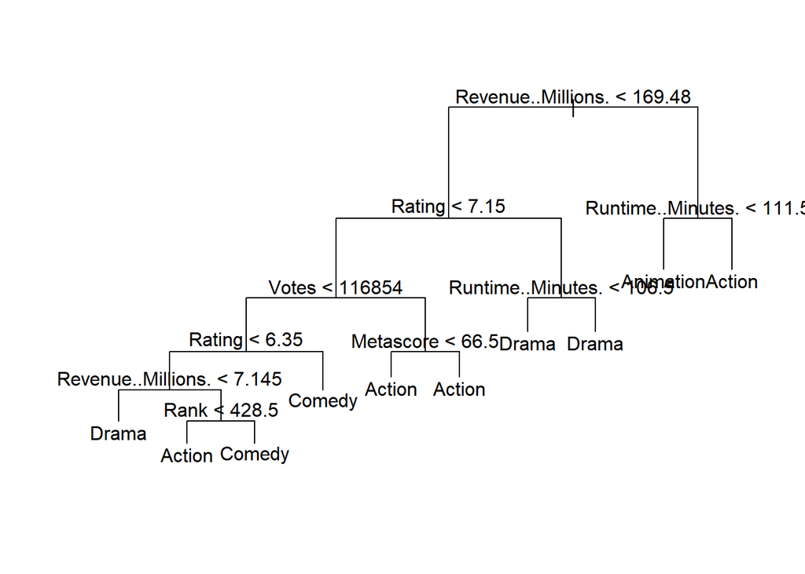

```r
set.seed(12412)
New_MovieDS$NewGenre <- factor(New_MovieDS$NewGenre)
bod <- data.frame(New_MovieDS)
bocl <- tree(NewGenre ~ Rank+Runtime..Minutes.+Rating+Votes+Revenue..Millions.+Metascore , data=bod)
plot(bocl)
text(bocl)
```

```r
summary(bocl)
```

```
##
## Classification tree:
## tree(formula = NewGenre ~ Rank + Runtime..Minutes. + Rating +
##     Votes + Revenue..Millions. + Metascore, data = bod)
## Number of terminal nodes:  10
## Residual mean deviance:  3.094 = 2562 / 828
## Misclassification error rate: 0.5609 = 470 / 838
```

## Prediction of classification tree

```r
tree_pre <- predict(bocl, test.data, type = "class")
Mean <-mean(tree_pre != testing_NewGenre)

MeanTest <- paste("Classification tree misclassification calculation with testing data. ", round(Mean,4))
MeanTest
```

```
## [1] "Classification tree misclassification calculation with testing data.  0.5728"
```

```r
table(tree_pre,testing_NewGenre)
```

```
##            testing_NewGenre
## tree_pre    Action Adventure Animation Biography Comedy Crime Drama
##   Action        87        17         3         1     24     1     7
##   Adventure      0         0         0         0      0     0     0
##   Animation      1         3        11         0      2     0     1
##   Biography      0         0         0         0      0     0     0
##   Comedy        19         8         1        10     31     2    22
##   Crime          0         0         0         0      0     0     0
##   Drama         13        10         4        14     23    19    50
##   Fantasy        0         0         0         0      0     0     0
##   Horror         0         0         0         0      0     0     0
##   Mystery        0         0         0         0      0     0     0
##   Sci-Fi         0         0         0         0      0     0     0
##   Thriller       0         0         0         0      0     0     0
##            testing_NewGenre
## tree_pre    Fantasy Horror Mystery Thriller
##   Action          2      8       1        0
##   Adventure       0      0       0        0
##   Animation       0      0       0        0
##   Biography       0      0       0        0
##   Comedy          0      8       2        1
##   Crime           0      0       0        0
##   Drama           0      7       6        0
##   Fantasy         0      0       0        0
##   Horror          0      0       0        0
##   Mystery         0      0       0        0
##   Sci-Fi          0      0       0        0
##   Thriller        0      0       0        0
```

## Pruning

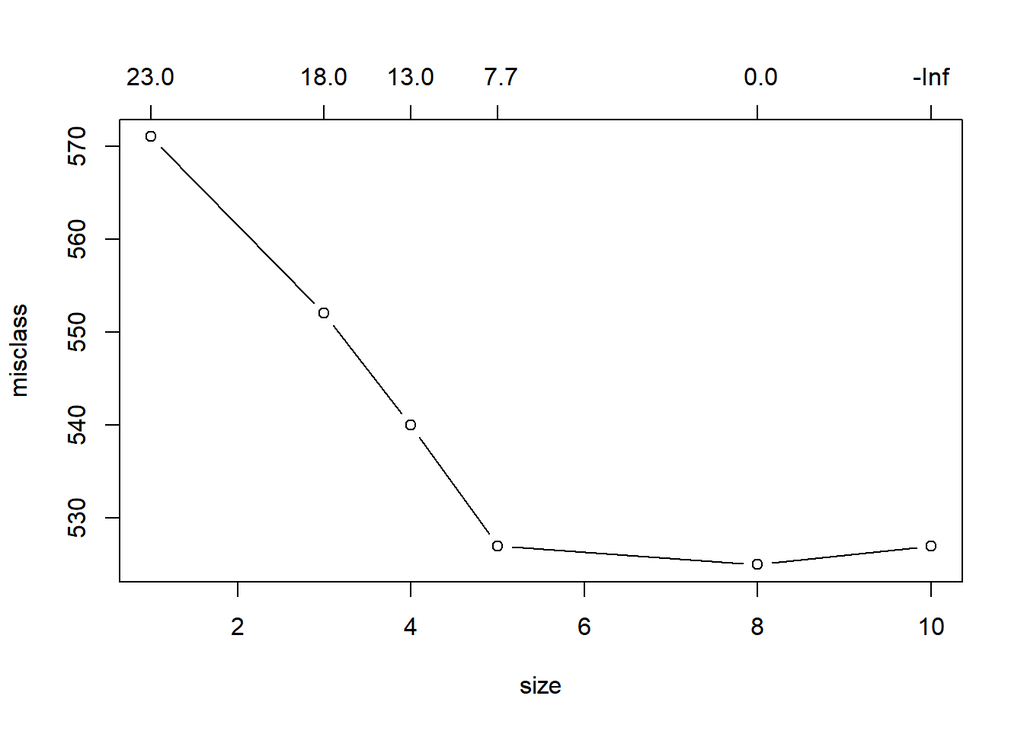

```r
cv.bocl <- cv.tree(bocl, FUN = prune.misclass)
plot(cv.bocl, type="b")
```

## Minimum is at 8

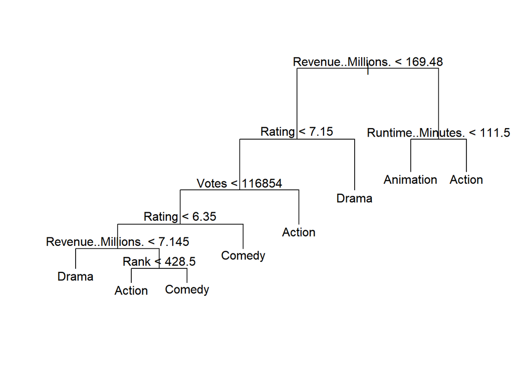

```r
p.bocl <- prune.misclass(bocl, best=8)
plot(p.bocl)
text(p.bocl)
```

```r
summary(p.bocl)
```

```
##
## Classification tree:
## snip.tree(tree = bocl, nodes = c(5L, 9L))
## Variables actually used in tree construction:
## [1] "Revenue..Millions." "Rating"             "Votes"
## [4] "Rank"               "Runtime..Minutes."
## Number of terminal nodes:  8
## Residual mean deviance:  3.19 = 2648 / 830
## Misclassification error rate: 0.5609 = 470 / 838
```

## Random Forest

```r
library(randomForest)
library(caret)
set.seed(1234)
#RandomForest <-randomForest(Revenue..Millions. ~ Runtime..Minutes. + Rating + Votes + Rank + Metascore ,data= train.data,importance=TRUE)
RandomForest <-randomForest(Rating ~  Votes + Runtime..Minutes.+Revenue..Millions.+Metascore+Rank,data= train.data,importance=TRUE)
RandomForest
```

```
##
## Call:
##  randomForest(formula = Rating ~ Votes + Runtime..Minutes. + Revenue..Millions. +      Metascore + Rank, data = train.data, importance = TRUE)
##                Type of random forest: regression
##                      Number of trees: 500
## No. of variables tried at each split: 1
##
##           Mean of squared residuals: 0.3296293
##                     % Var explained: 55.5
```

```r
##Predicting random forest.
p1 <- predict(RandomForest,test.data)
paste("Predicting Random Forest with testing dataset ",round(mean((p1-test.data$Rating)^2),6))
```

```
## [1] "Predicting Random Forest with testing dataset  0.366853"
```

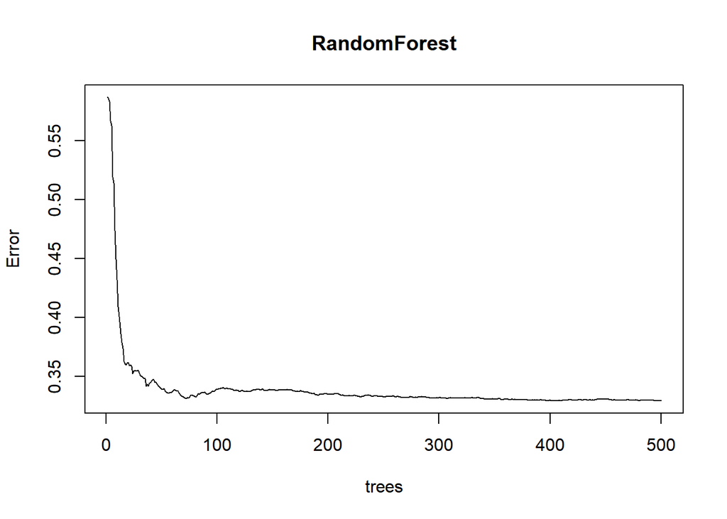

```r
plot(RandomForest)
```

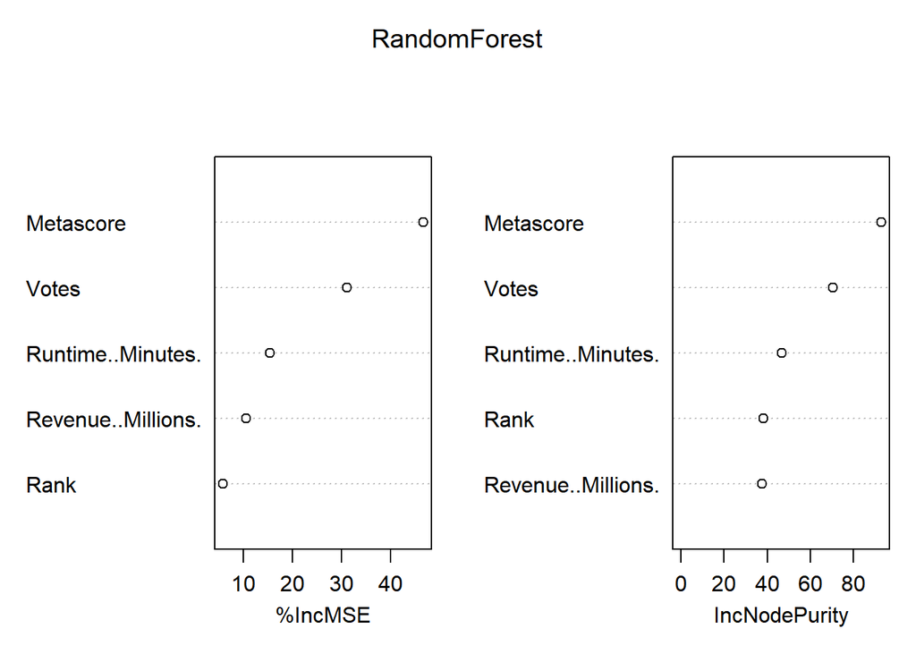

```r
varImpPlot(RandomForest)
```

```r
##Tune mtry
#train.data
#t <- tuneRF(train.data[,-c(2,3,4,5,6,7,9)], train.data[,9], stepFactor = .5, plot = TRUE, ntreeTry = 300, trace = TRUE, improve = 0.05)
#RandomForestTune <-randomForest(Rating ~  Votes + Runtime..Minutes.+Revenue..Millions.+Metascore+Rank,data= train.data,mtry=2,importance=TRUE)
#RandomForestTune
```

## Clustering

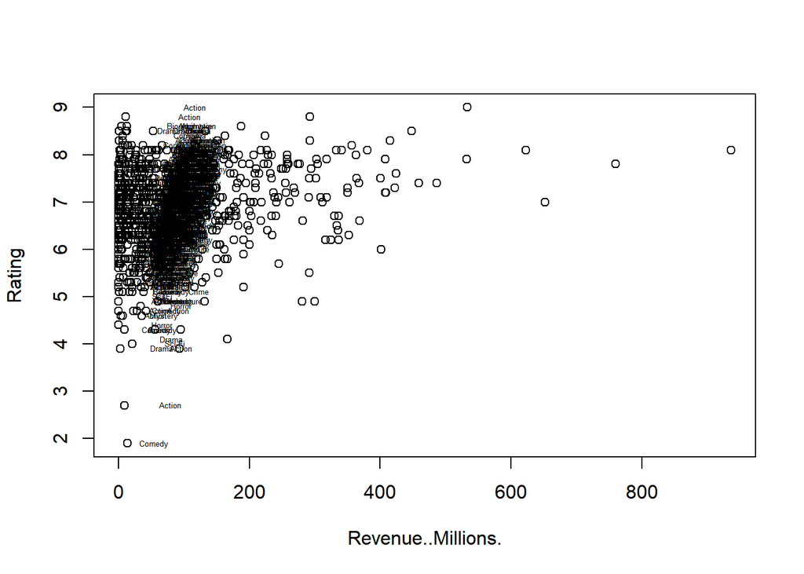

```r
#Scatter plot
plot(Rating ~ Revenue..Millions.)
with(New_MovieDS,text(Rating ~ Metascore , label = NewGenre, pos= 4, cex = .4))
```

# Normalization

```r
z <- New_MovieDS[,-c(2,3,4,5,6,7,13)]
m <- apply(z, 2, mean)
s <- apply(z, 2, sd)
z <- scale(z,m,s)
```

```r
#calculating Euclidean Distance
distance <- dist(z)
#print(distance,digits = 3)
```

# Cluster Dendrogram with complete linkage

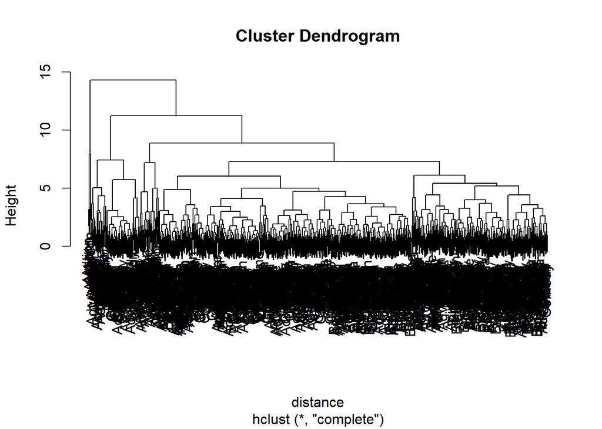

```r
hc.c <- hclust(distance)
plot(hc.c, label= New_MovieDS$NewGenre)
```

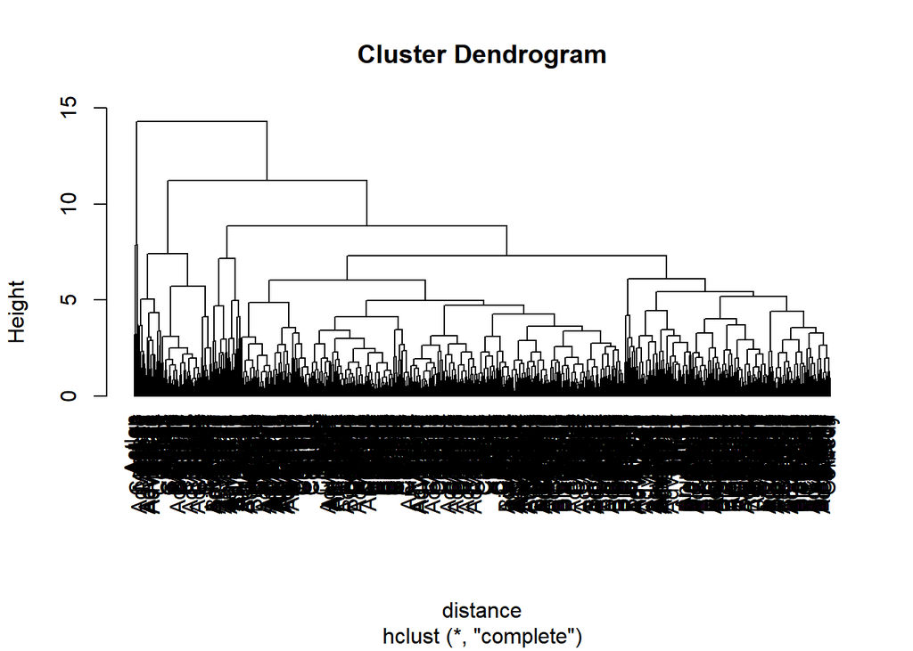

```r
plot(hc.c, label= New_MovieDS$NewGenre,hang = -1)
```

## Clustering Dendrogram with average Linkage

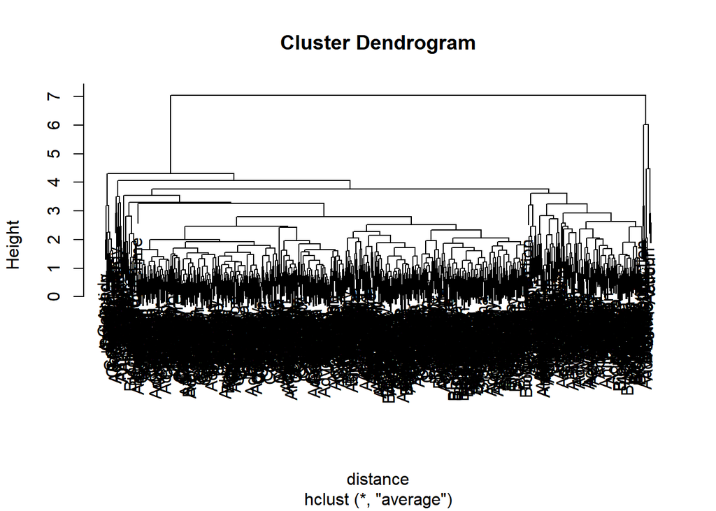

```r
hc.a <- hclust(distance, method = "average")
plot(hc.a, label= New_MovieDS$NewGenre)
```

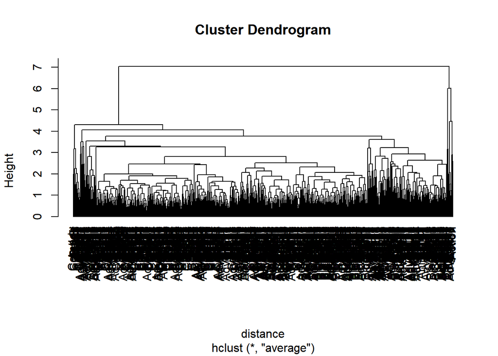

```r
plot(hc.a, label= New_MovieDS$NewGenre,hang = -1)
```

## Clsuter Membership

```r
member.c <- cutree(hc.c,3)
member.a <- cutree(hc.a,3)
table(member.c,member.a)
```

```
##         member.a
## member.c   1   2   3
##        1 737   7   0
##        2  88   0   0
##        3   0   3   3
```

## Cluster Mean

```r
aggregate(z,list(member.c),mean)
```

```
##   Group.1        Rank Runtime..Minutes.    Rating        Votes
## 1       1 -0.07195633       0.004294161  0.149064 -0.008690256
## 2       2  0.70489419      -0.169911649 -1.382145 -0.284411166
## 3       3 -1.41586382       1.959561543  1.787533  5.248955483
##   Revenue..Millions. Metascore
## 1        -0.06553693  0.135029
## 2         0.21845477 -1.215042
## 3         4.92257616  1.077024
```

```r
aggregate(New_MovieDS[,-c(2,3,4,5,6,7,13)], list(member.c),mean)
```

```
##   Group.1     Rank Runtime..Minutes.   Rating     Votes Revenue..Millions.
## 1       1 464.6263          114.7177 6.945161  191552.2           77.71462
## 2       2 687.2500          111.5000 5.601136  138310.7          107.39750
## 3       3  79.5000          150.8333 8.383333 1206798.3          599.07333
##   Metascore
## 1  61.86425
## 2  38.97727
## 3  77.83333
```

## ScreePlot

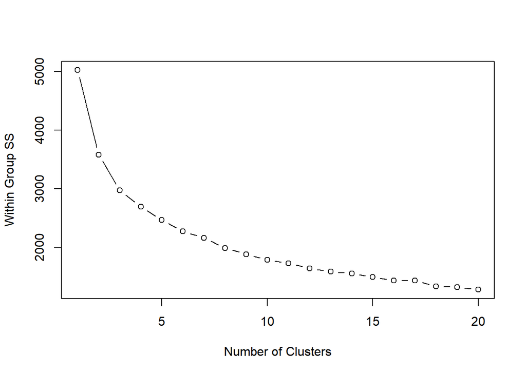

```r
WSS <- (nrow(z)-1)*sum(apply(z,2,var))
for(i in 2:20) WSS[i] <- sum(kmeans(z,centers=i)$withinss)
plot(1:20, WSS, type = "b", xlab = "Number of Clusters", ylab = "Within Group SS")
```

Scree plot descibes that the within group ss is dropped significantly, when there are only 3 or 4 cluster.

## Kmeans

```r
Kc <- kmeans(New_MovieDS[,-c(2,3,4,5,6,7,13)],4)
Kc
```

```
## K-means clustering with 4 clusters of sizes 483, 12, 242, 101
##
## Cluster means:
##        Rank Runtime..Minutes.   Rating      Votes Revenue..Millions.
## 1 530.29607          109.5259 6.493582   73689.11            40.1271
## 2  89.41667          154.5833 8.400000 1099701.08           296.6175
## 3 500.07438          118.9298 7.035124  257299.18           112.3012
## 4 281.31683          124.0594 7.630693  503686.09           205.4200
##   Metascore
## 1  55.59006
## 2  74.91667
## 3  61.82231
## 4  71.42574
##
## Clustering vector:
```

[output cut: 122 more lines]

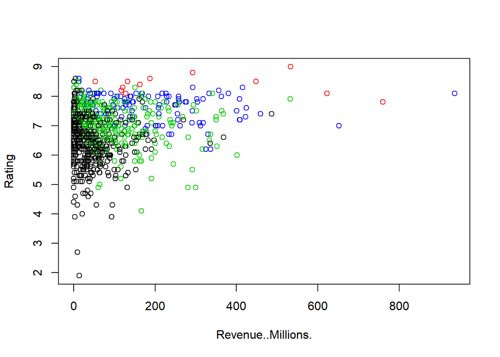

```r
plot(Rating ~ Revenue..Millions., New_MovieDS , col = Kc$cluster)
```

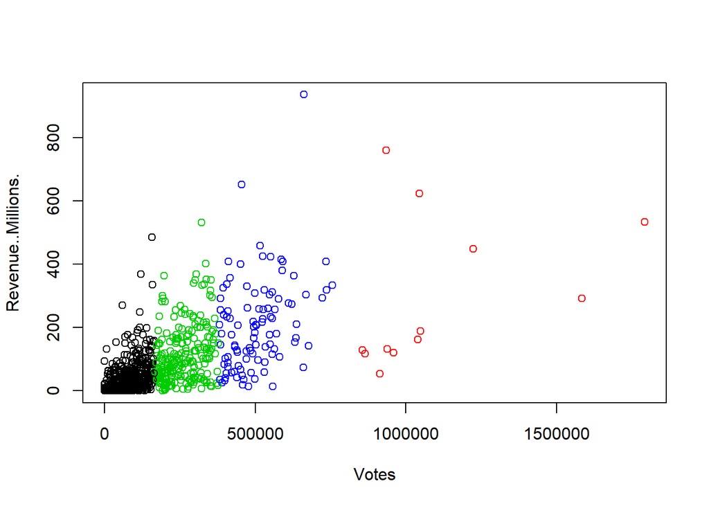

```r
plot(Revenue..Millions. ~ Votes, New_MovieDS , col = Kc$cluster)
```

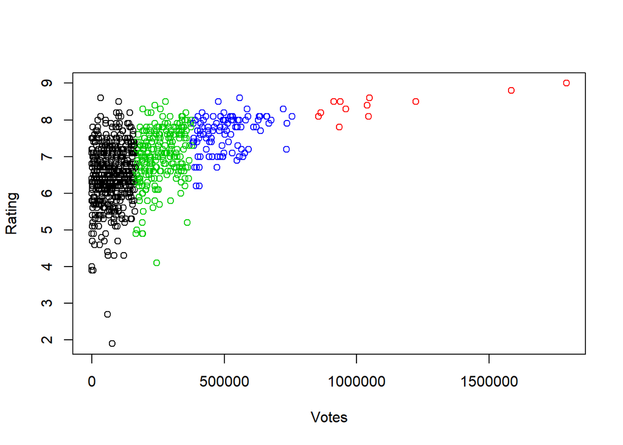

```r
plot(Rating ~ Votes, New_MovieDS , col = Kc$cluster)
```

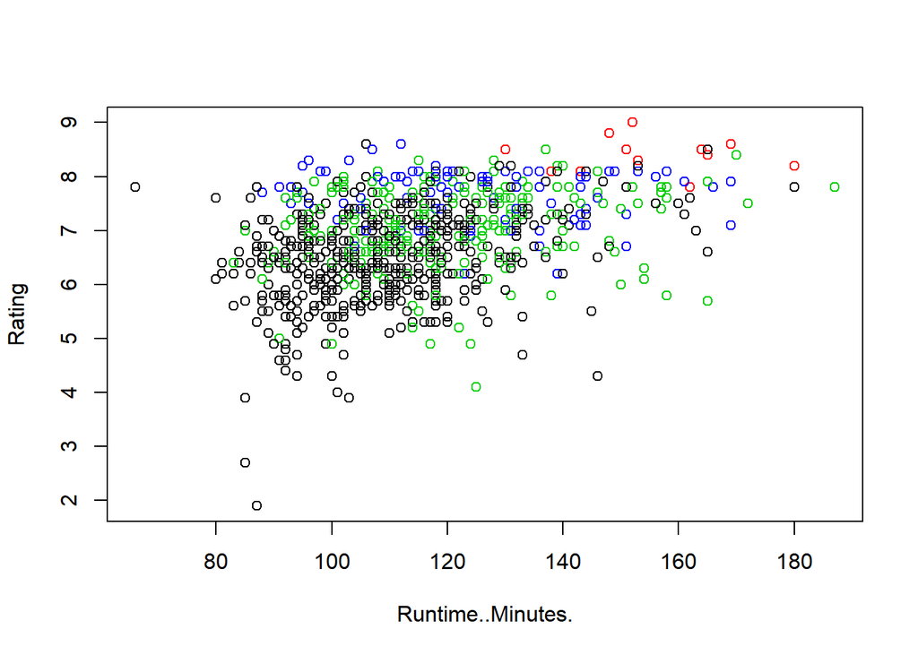

```r
plot(Rating ~ Runtime..Minutes. , New_MovieDS , col = Kc$cluster)
```

```r
#plot(Metascore ~ Revenue..Millions. , New_MovieDS , col = Kc$cluster)
#plot(Revenue..Millions.~ Metascore , New_MovieDS , col = Kc$cluster)
```

## Multiple Linear Regression

```r
#attach(New_MovieDS)
mlr <- lm(Rating ~  Votes + Runtime..Minutes.+Revenue..Millions.+Metascore+Rank)
mlr2 <- lm(Rating ~  Votes + Runtime..Minutes.+Revenue..Millions.+Metascore)
summary(mlr)
```

```
##
## Call:
## lm(formula = Rating ~ Votes + Runtime..Minutes. + Revenue..Millions. +
##     Metascore + Rank)
##
## Residuals:
##     Min      1Q  Median      3Q     Max
## -3.3514 -0.2852  0.0305  0.3277  1.9285
##
## Coefficients:
##                      Estimate Std. Error t value Pr(>|t|)
## (Intercept)         4.210e+00  1.549e-01  27.172  < 2e-16 ***
## Votes               1.640e-06  1.455e-07  11.272  < 2e-16 ***
## Runtime..Minutes.   6.804e-03  1.187e-03   5.731 1.39e-08 ***
## Revenue..Millions. -1.153e-03  2.485e-04  -4.639 4.06e-06 ***
## Metascore           2.769e-02  1.257e-03  22.028  < 2e-16 ***
## Rank               -9.186e-05  7.410e-05  -1.240    0.215
## ---
## Signif. codes:  0 '***' 0.001 '**' 0.01 '*' 0.05 '.' 0.1 ' ' 1
##
## Residual standard error: 0.5723 on 832 degrees of freedom
##   (162 observations deleted due to missingness)
## Multiple R-squared:  0.5775, Adjusted R-squared:  0.5749
## F-statistic: 227.4 on 5 and 832 DF,  p-value: < 2.2e-16
```

```r
summary(mlr2)
```

```
##
## Call:
## lm(formula = Rating ~ Votes + Runtime..Minutes. + Revenue..Millions. +
##     Metascore)
##
## Residuals:
##     Min      1Q  Median      3Q     Max
## -3.3659 -0.2844  0.0301  0.3440  1.8789
##
## Coefficients:
##                      Estimate Std. Error t value Pr(>|t|)
## (Intercept)         4.126e+00  1.395e-01  29.587  < 2e-16 ***
## Votes               1.656e-06  1.449e-07  11.432  < 2e-16 ***
## Runtime..Minutes.   7.009e-03  1.176e-03   5.960 3.73e-09 ***
## Revenue..Millions. -1.118e-03  2.470e-04  -4.526 6.89e-06 ***
## Metascore           2.785e-02  1.251e-03  22.268  < 2e-16 ***
## ---
## Signif. codes:  0 '***' 0.001 '**' 0.01 '*' 0.05 '.' 0.1 ' ' 1
##
## Residual standard error: 0.5724 on 833 degrees of freedom
##   (162 observations deleted due to missingness)
## Multiple R-squared:  0.5767, Adjusted R-squared:  0.5747
## F-statistic: 283.7 on 4 and 833 DF,  p-value: < 2.2e-16
```

## Ridge Regression

```r
library(glmnet)
```

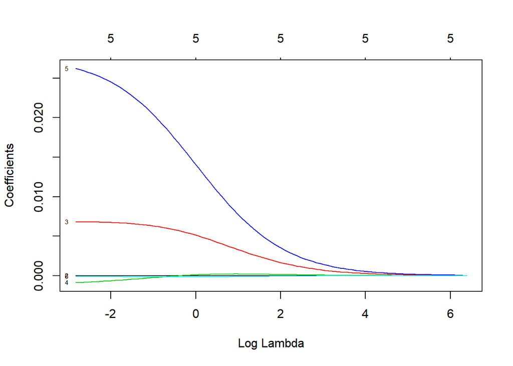

```r
set.seed(1234)
x = model.matrix(Rating ~  Votes + Runtime..Minutes.+Revenue..Millions.+Metascore+Rank, data = New_MovieDS)
y = New_MovieDS$Rating
rrsim_d <- cv.glmnet(x, y, alpha=0)
plot(rrsim_d$glmnet.fit, label=TRUE, xvar="lambda")
```

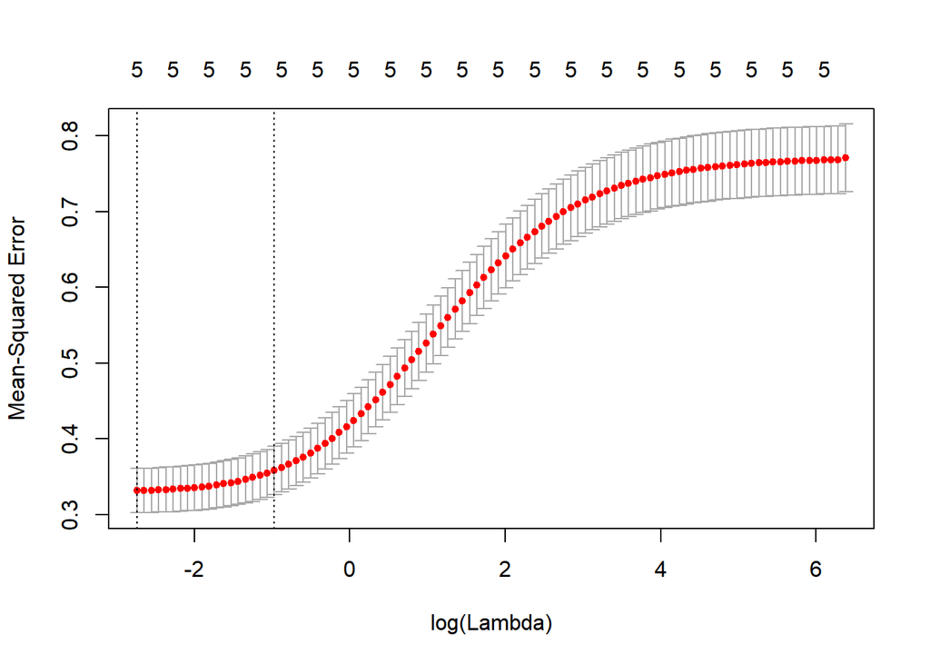

```r
plot(rrsim_d)
```

```r
rrsim_d$lambda.min
```

```
## [1] 0.06476778
```

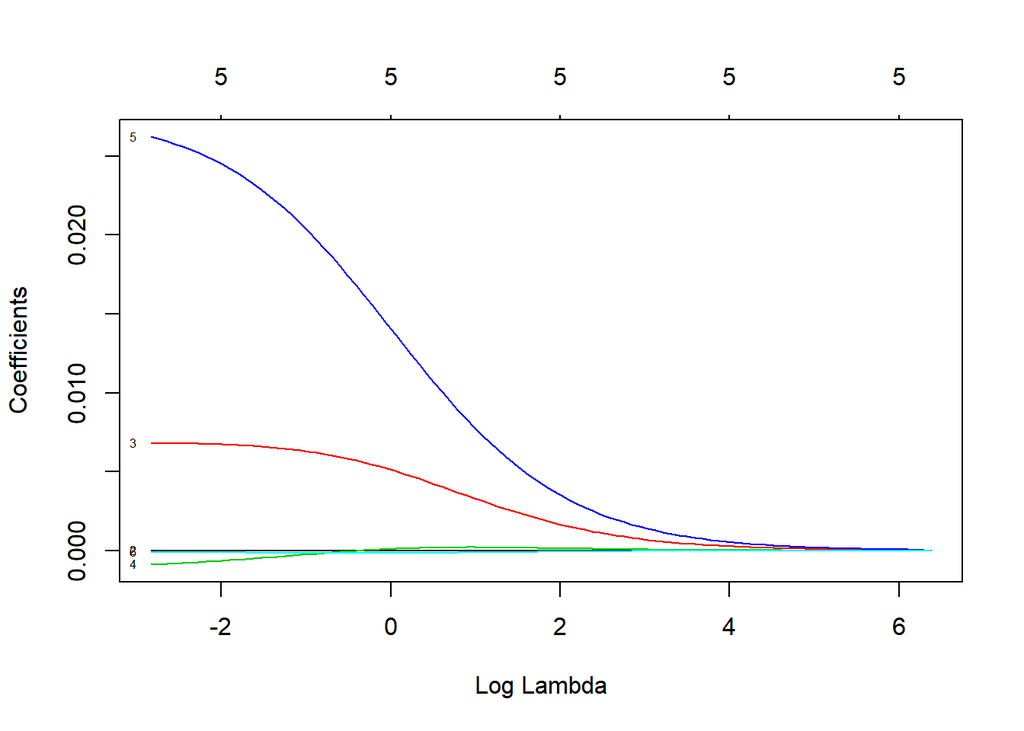

```r
set.seed(451642)
rrsim <- cv.glmnet(x, y, alpha=0)
plot(rrsim$glmnet.fit, label=TRUE, xvar="lambda")
```

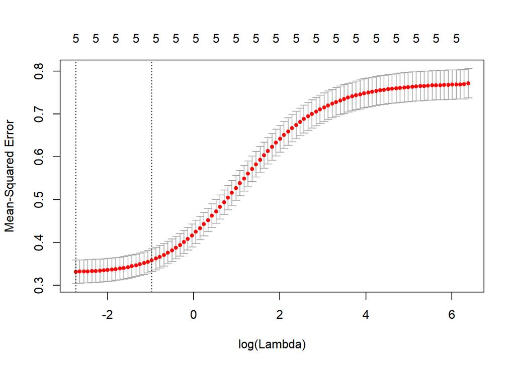

```r
plot(rrsim)
```

```r
rrsim$lambda.min
```

```
## [1] 0.06476778
```

```r
lammin <- rrsim$lambda.min
lam1se <- rrsim$lambda.1se
rrsimmin <- glmnet(x,y,alpha = 0, lambda=lammin)
rrsim1se <- glmnet(x,y,alpha = 0, lambda=lam1se)
coef(rrsimmin)
```

```
## 7 x 1 sparse Matrix of class "dgCMatrix"
##                               s0
## (Intercept)         4.321161e+00
## (Intercept)         .
## Votes               1.471316e-06
## Runtime..Minutes.   6.806161e-03
## Revenue..Millions. -8.663904e-04
## Metascore           2.609096e-02
## Rank               -1.081899e-04
```

```r
coef(rrsim1se)
```

```
## 7 x 1 sparse Matrix of class "dgCMatrix"
##                               s0
## (Intercept)         4.772874e+00
## (Intercept)         .
## Votes               1.070737e-06
## Runtime..Minutes.   6.284091e-03
## Revenue..Millions. -2.281794e-04
## Metascore           2.022528e-02
## Rank               -1.473053e-04
```

```r
coeftab <- cbind(coef(mlr), coef(rrsimmin), coef(rrsim1se))
colnames(coeftab) <- c("MLM", "RidgeRegMin", "RidgeReg1se")
round(coeftab,5)
```

```
## 7 x 3 sparse Matrix of class "dgCMatrix"
##                         MLM RidgeRegMin RidgeReg1se
## (Intercept)         4.21018     4.32116     4.77287
## (Intercept)         0.00000     .           .
## Votes               0.00680     0.00000     0.00000
## Runtime..Minutes.  -0.00115     0.00681     0.00628
## Revenue..Millions.  0.02769    -0.00087    -0.00023
## Metascore          -0.00009     0.02609     0.02023
## Rank                4.21018    -0.00011    -0.00015
```

## Lasso

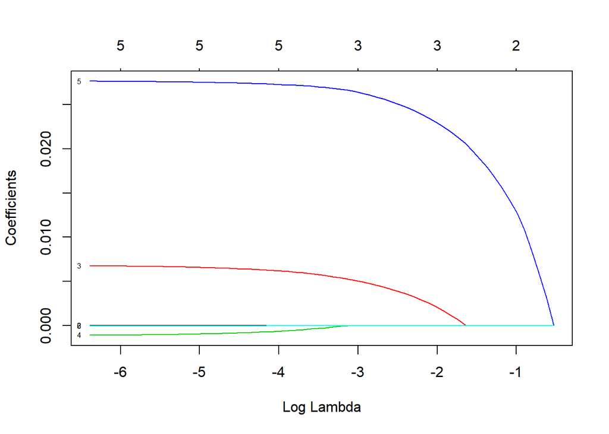

```r
lasim <- cv.glmnet(x, y, alpha=1)
plot(lasim$glmnet.fit, label=TRUE, xvar="lambda")
```

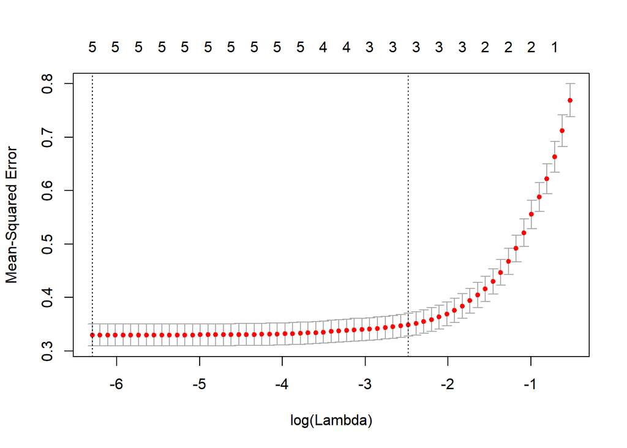

```r
plot(lasim)
```

```r
lammin <- lasim$lambda.min
lam1se <- lasim$lambda.1se
lasimmin <- glmnet(x,y,alpha = 1, lambda=lammin)
lasim1se <- glmnet(x,y,alpha = 1, lambda=lam1se)
coef(lasimmin)
```

```
## 7 x 1 sparse Matrix of class "dgCMatrix"
##                               s0
## (Intercept)         4.216878e+00
## (Intercept)         .
## Votes               1.617926e-06
## Runtime..Minutes.   6.740096e-03
## Revenue..Millions. -1.101472e-03
## Metascore           2.764789e-02
## Rank               -8.623892e-05
```

```r
coef(lasim1se)
```

```
## 7 x 1 sparse Matrix of class "dgCMatrix"
##                              s0
## (Intercept)        4.682491e+00
## (Intercept)        .
## Votes              1.041282e-06
## Runtime..Minutes.  3.836719e-03
## Revenue..Millions. .
## Metascore          2.502362e-02
## Rank               .
```

```r
coeftab <- cbind(coef(mlr), coef(rrsimmin), coef(lasimmin))
colnames(coeftab) <- c("MLM", "RidgeRegMin", "LassoMin")
round(coeftab,5)
```

```
## 7 x 3 sparse Matrix of class "dgCMatrix"
##                         MLM RidgeRegMin LassoMin
## (Intercept)         4.21018     4.32116  4.21688
## (Intercept)         0.00000     .        .
## Votes               0.00680     0.00000  0.00000
## Runtime..Minutes.  -0.00115     0.00681  0.00674
## Revenue..Millions.  0.02769    -0.00087 -0.00110
## Metascore          -0.00009     0.02609  0.02765
## Rank                4.21018    -0.00011 -0.00009
```

## Regression tree

for rating

```r
library(tree)
library(MASS)
#New_MovieDS
#test.data
#train.data
treeMove<- tree(New_MovieDS$Rating~Rank+factor(NewGenre)+Year+Runtime..Minutes.+Votes+Revenue..Millions.+Metascore,New_MovieDS)
summary(treeMove)
```

```
##
## Regression tree:
## tree(formula = New_MovieDS$Rating ~ Rank + factor(NewGenre) +
##     Year + Runtime..Minutes. + Votes + Revenue..Millions. + Metascore,
##     data = New_MovieDS)
## Variables actually used in tree construction:
## [1] "Metascore"         "Runtime..Minutes." "factor(NewGenre)"
## [4] "Votes"
## Number of terminal nodes:  12
## Residual mean deviance:  0.3186 = 263.1 / 826
## Distribution of residuals:
##    Min. 1st Qu.  Median    Mean 3rd Qu.    Max.
## -3.5880 -0.2883  0.0117  0.0000  0.3442  1.9120
```

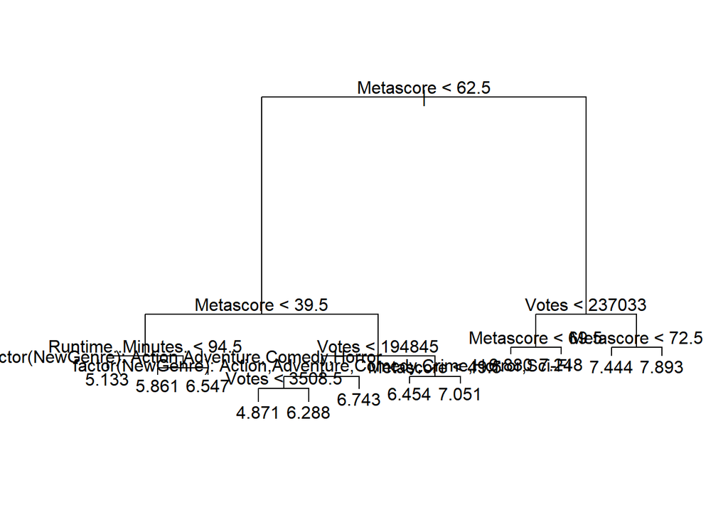

```r
plot(treeMove)
text(treeMove, pretty=0)
```

```r
#cvMove<- cv.tree(treeMove)
#summary(cvMove)
#plot(cvMove)
#pruneMove <- prune.tree(treeMove, best =6)
#plot(pruneMove)
#text(pruneMove, pretty=0)
treeMove2<- tree(New_MovieDS$Rating~Rank+factor(NewGenre)+Year+Runtime..Minutes.+Votes+Revenue..Millions.+Metascore,New_MovieDS, subset=train)
summary(treeMove2)
```

```
##
## Regression tree:
## tree(formula = New_MovieDS$Rating ~ Rank + factor(NewGenre) +
##     Year + Runtime..Minutes. + Votes + Revenue..Millions. + Metascore,
##     data = New_MovieDS, subset = train)
## Variables actually used in tree construction:
## [1] "Metascore"         "Runtime..Minutes." "factor(NewGenre)"
## [4] "Votes"
## Number of terminal nodes:  11
## Residual mean deviance:  0.2797 = 114.1 / 408
## Distribution of residuals:
##     Min.  1st Qu.   Median     Mean  3rd Qu.     Max.
## -2.72700 -0.29610  0.01111  0.00000  0.31110  1.67300
```

```r
cvMove<- cv.tree(treeMove2)
summary(cvMove)
```

```
##        Length Class  Mode
## size   11     -none- numeric
## dev    11     -none- numeric
## k      11     -none- numeric
## method  1     -none- character
```

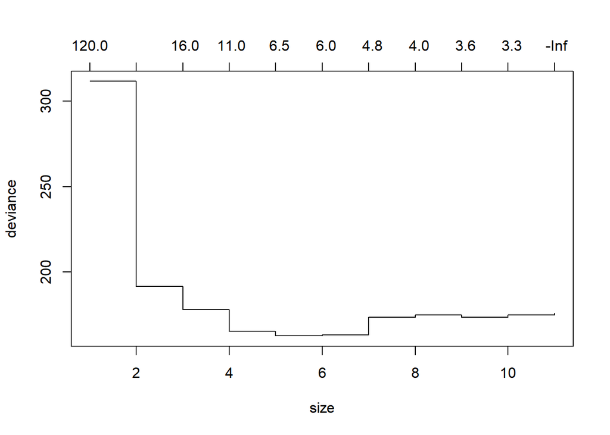

```r
plot(cvMove)
```

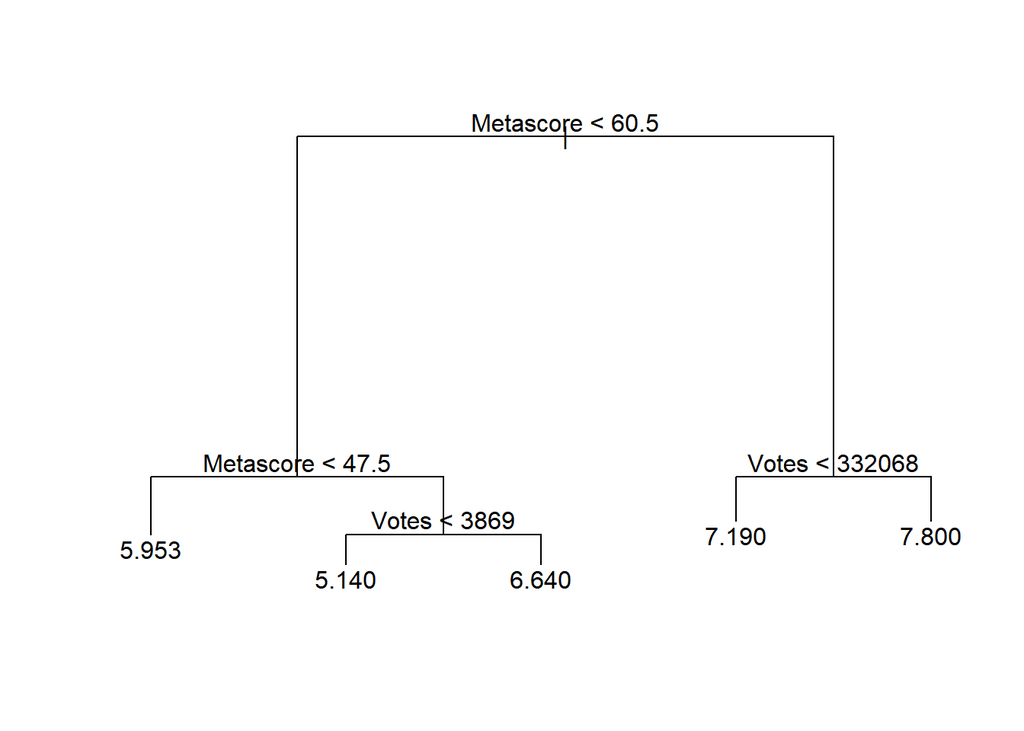

```r
pruneMove <- prune.tree(treeMove2, best =5)
plot(pruneMove)
text(pruneMove, pretty=0)
```

```r
yhat<- predict(treeMove2, newdata=test.data )
MoveTest<- New_MovieDS[-train, "Rating"]
mean((yhat-MoveTest)^2)
```

```
## [1] 0.4642014
```

Using set.seed(1234) MSE is 0.4642014 so this tree predicts rating within .68 of the true response. Which is not bad.

For Rank

```r
treeMove3<- tree(New_MovieDS$Rank~Rating+factor(NewGenre)+Year+Runtime..Minutes.+Votes+Revenue..Millions.+Metascore,New_MovieDS)
summary(treeMove3)
```

```
##
## Regression tree:
## tree(formula = New_MovieDS$Rank ~ Rating + factor(NewGenre) +
##     Year + Runtime..Minutes. + Votes + Revenue..Millions. + Metascore,
##     data = New_MovieDS)
## Variables actually used in tree construction:
## [1] "Year"              "Votes"             "Runtime..Minutes."
## [4] "factor(NewGenre)"
## Number of terminal nodes:  12
## Residual mean deviance:  41470 = 34260000 / 826
## Distribution of residuals:
##     Min.  1st Qu.   Median     Mean  3rd Qu.     Max.
## -562.600 -134.900   -1.527    0.000  150.900  541.400
```

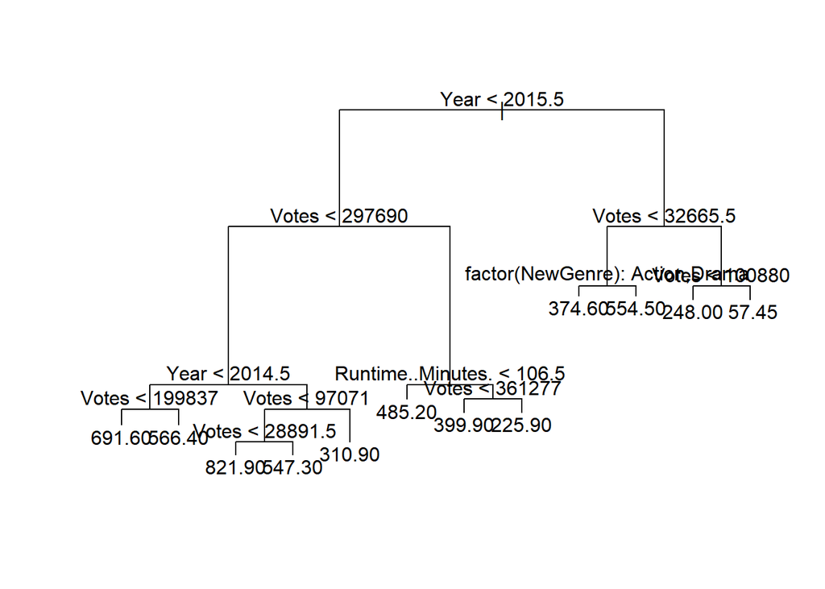

```r
plot(treeMove3)
text(treeMove3, pretty=0)
```

```r
#cvMove2<- cv.tree(treeMove3)
#summary(cvMove2)
#plot(cvMove2)
#pruneMove2 <- prune.tree(treeMove3, best =6)
#plot(pruneMove2)
#text(pruneMove2, pretty=0)
treeMove4<- tree(New_MovieDS$Rank~Rating+factor(NewGenre)+Year+Runtime..Minutes.+Votes+Revenue..Millions.+Metascore,New_MovieDS, subset=train)
summary(treeMove4)
```

```
##
## Regression tree:
## tree(formula = New_MovieDS$Rank ~ Rating + factor(NewGenre) +
##     Year + Runtime..Minutes. + Votes + Revenue..Millions. + Metascore,
##     data = New_MovieDS, subset = train)
## Variables actually used in tree construction:
## [1] "Year"               "Votes"              "Revenue..Millions."
## [4] "Rating"             "Runtime..Minutes."  "factor(NewGenre)"
## Number of terminal nodes:  12
## Residual mean deviance:  39480 = 16070000 / 407
## Distribution of residuals:
##    Min. 1st Qu.  Median    Mean 3rd Qu.    Max.
##  -553.7  -131.5   -10.2     0.0   148.0   619.1
```

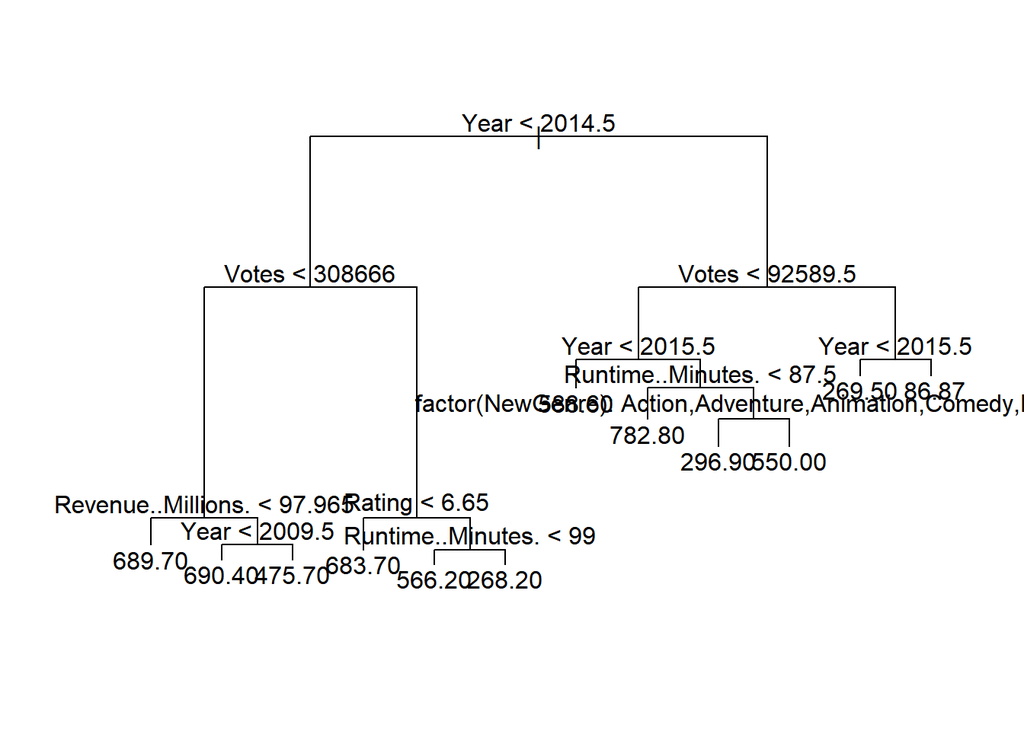

```r
plot(treeMove4)
text(treeMove4, pretty=0)
```

```r
cvMove2<- cv.tree(treeMove4)
summary(cvMove2)
```

```
##        Length Class  Mode
## size   10     -none- numeric
## dev    10     -none- numeric
## k      10     -none- numeric
## method  1     -none- character
```

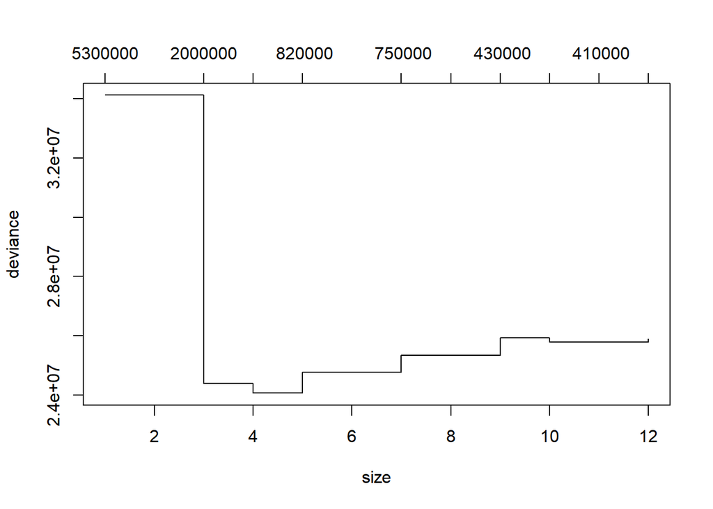

```r
plot(cvMove2)
```

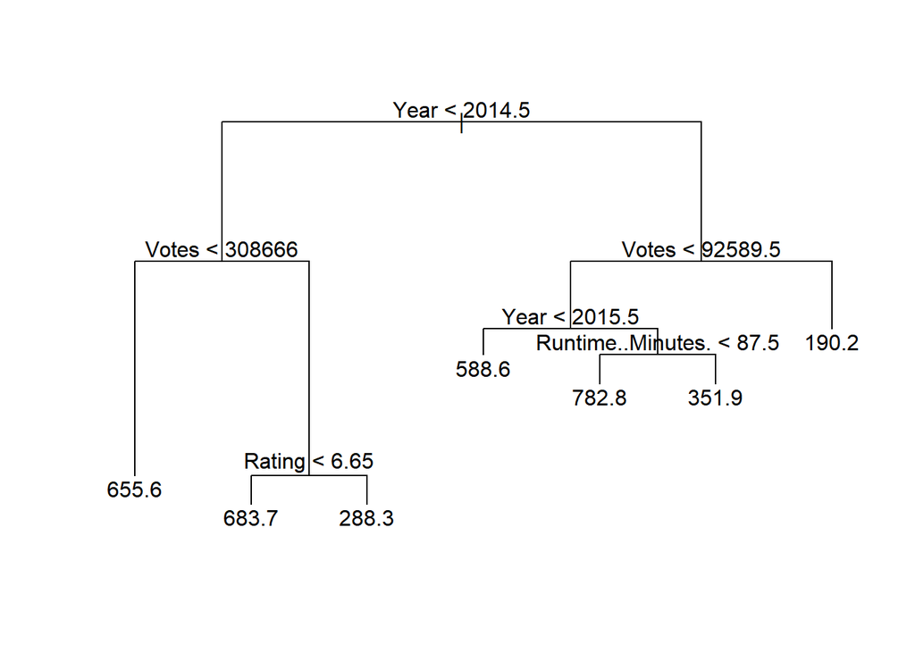

```r
pruneMove2 <- prune.tree(treeMove4, best =6)
plot(pruneMove2)
text(pruneMove2, pretty=0)
```

```r
yhat2<- predict(treeMove4, newdata=test.data)
MoveTest2<- New_MovieDS[-train, "Rank"]
mean((yhat2-MoveTest2)^2)
```

```
## [1] 54973
```

MSE is 54973 so this tree predicts rank within 234.46 of the true response. Not very good

For NewGenre

```r
treeMove5<- tree(New_MovieDS$NewGenre~Rank+Year+Runtime..Minutes.+Rating+Votes+Revenue..Millions.+Metascore,New_MovieDS)
summary(treeMove5)
```

```
##
## Classification tree:
## tree(formula = New_MovieDS$NewGenre ~ Rank + Year + Runtime..Minutes. +
##     Rating + Votes + Revenue..Millions. + Metascore, data = New_MovieDS)
## Variables actually used in tree construction:
## [1] "Revenue..Millions." "Rating"             "Votes"
## [4] "Rank"               "Metascore"          "Runtime..Minutes."
## Number of terminal nodes:  10
## Residual mean deviance:  3.094 = 2562 / 828
## Misclassification error rate: 0.5609 = 470 / 838
```

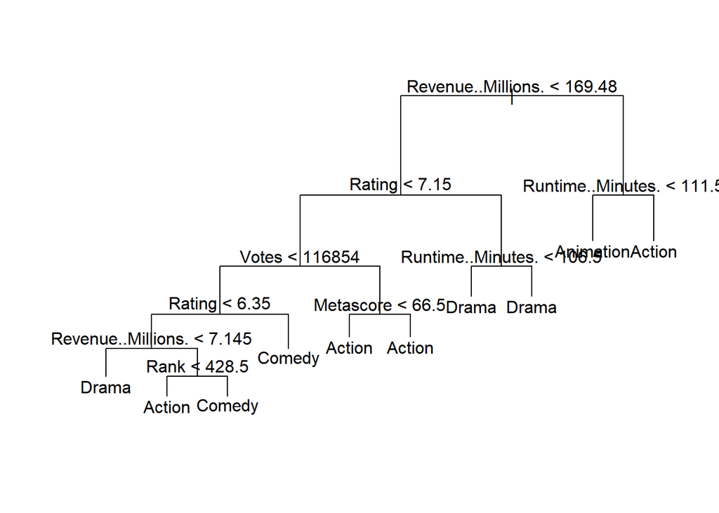

```r
plot(treeMove5)
text(treeMove5, pretty=0)
```

```r
#cvMove3<- cv.tree(treeMove5)
#summary(cvMove3)
#plot(cvMove3)
#pruneMove3 <- prune.tree(treeMove5, best =6)
#plot(pruneMove3)
#text(pruneMove3, pretty=0)
treeMove6<- tree(New_MovieDS$NewGenre~Rank+Year+Runtime..Minutes.+Rating+Votes+Revenue..Millions.+Metascore,New_MovieDS, subset=train)
summary(treeMove6)
```

```
##
## Classification tree:
## tree(formula = New_MovieDS$NewGenre ~ Rank + Year + Runtime..Minutes. +
##     Rating + Votes + Revenue..Millions. + Metascore, data = New_MovieDS,
##     subset = train)
## Variables actually used in tree construction:
## [1] "Revenue..Millions." "Rating"             "Votes"
## [4] "Metascore"          "Runtime..Minutes."  "Rank"
## Number of terminal nodes:  17
## Residual mean deviance:  2.595 = 1043 / 402
## Misclassification error rate: 0.5155 = 216 / 419
```

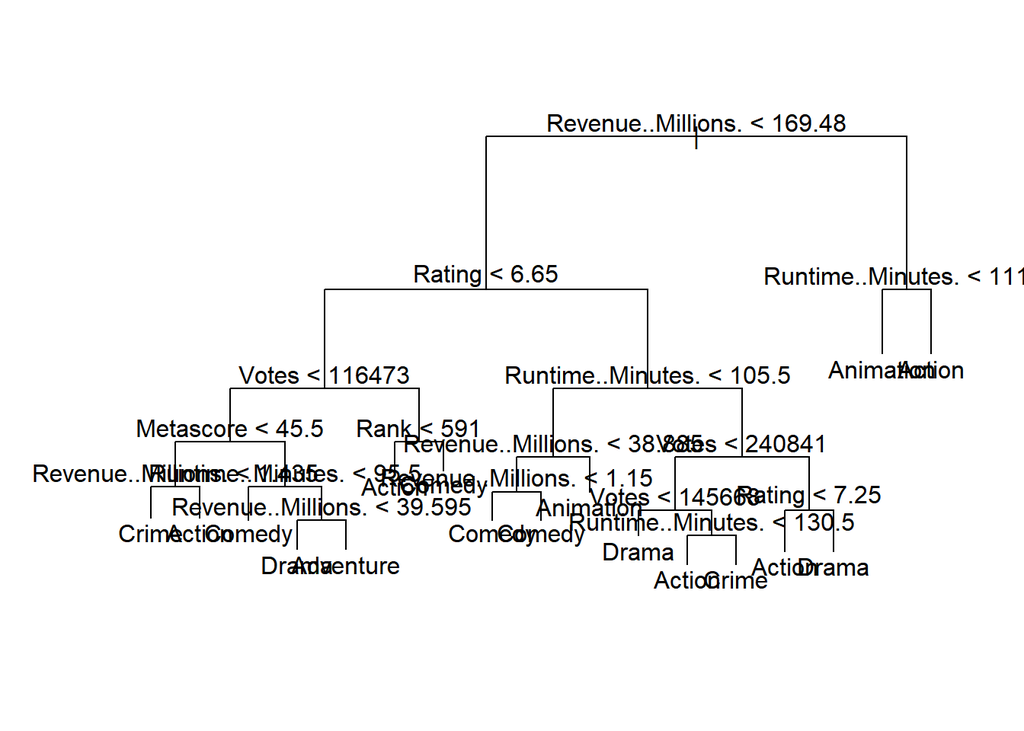

```r
plot(treeMove6)
text(treeMove6, pretty=0)
```

```r
cvMove3<- cv.tree(treeMove6)
summary(cvMove3)
```

```
##        Length Class  Mode
## size   16     -none- numeric
## dev    16     -none- numeric
## k      16     -none- numeric
## method  1     -none- character
```

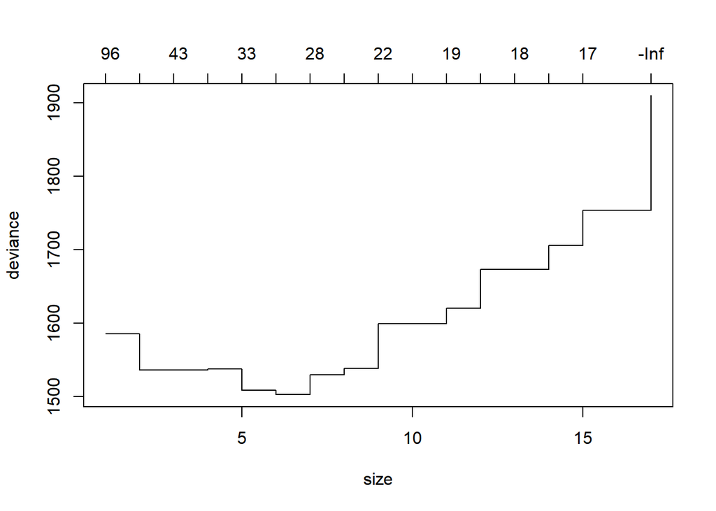

```r
plot(cvMove3)
```

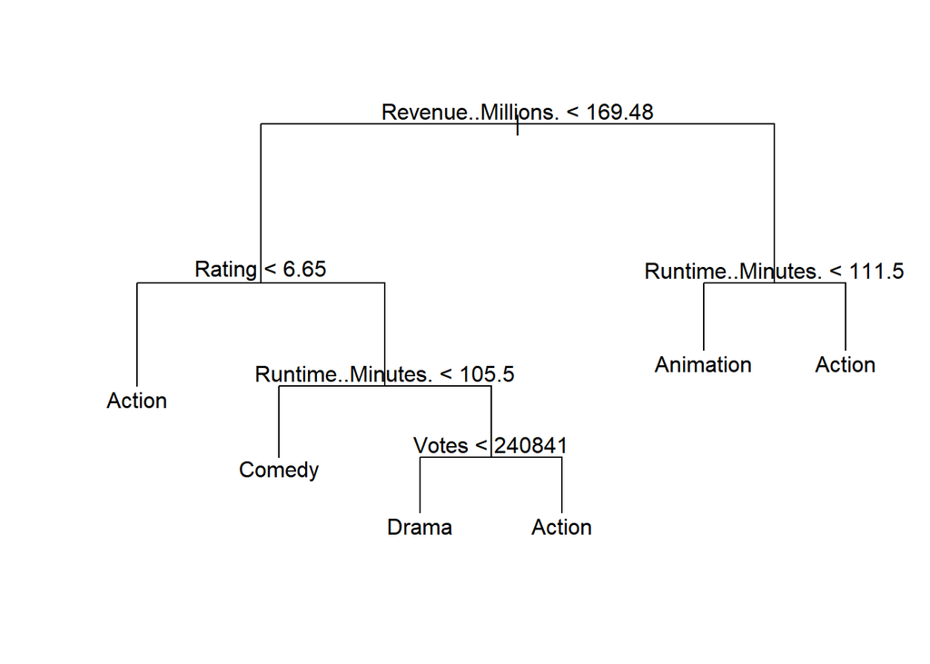

```r
pruneMove3 <- prune.tree(treeMove6, best =6)
plot(pruneMove3)
text(pruneMove3, pretty=0)
```

```r
yhat3<- predict(treeMove6, newdata=test.data)
MoveTest3<- New_MovieDS[-train, "NewGenre"]
mean((yhat3-MoveTest3)^2)
```

```
## [1] NA
```

MSE is NA which makes sense as NewGenre is catagorical so a regression tree is not a good method of prediction

FOr revenue

```r
treeMove7<- tree(New_MovieDS$Revenue..Millions.~Rank+factor(NewGenre)+Year+Runtime..Minutes.+Rating+Votes+Metascore,New_MovieDS)
summary(treeMove7)
```

```
##
## Regression tree:
## tree(formula = New_MovieDS$Revenue..Millions. ~ Rank + factor(NewGenre) +
##     Year + Runtime..Minutes. + Rating + Votes + Metascore, data = New_MovieDS)
## Number of terminal nodes:  13
## Residual mean deviance:  3932 = 3244000 / 825
## Distribution of residuals:
##    Min. 1st Qu.  Median    Mean 3rd Qu.    Max.
## -342.50  -29.86  -12.61    0.00   25.40  440.50
```

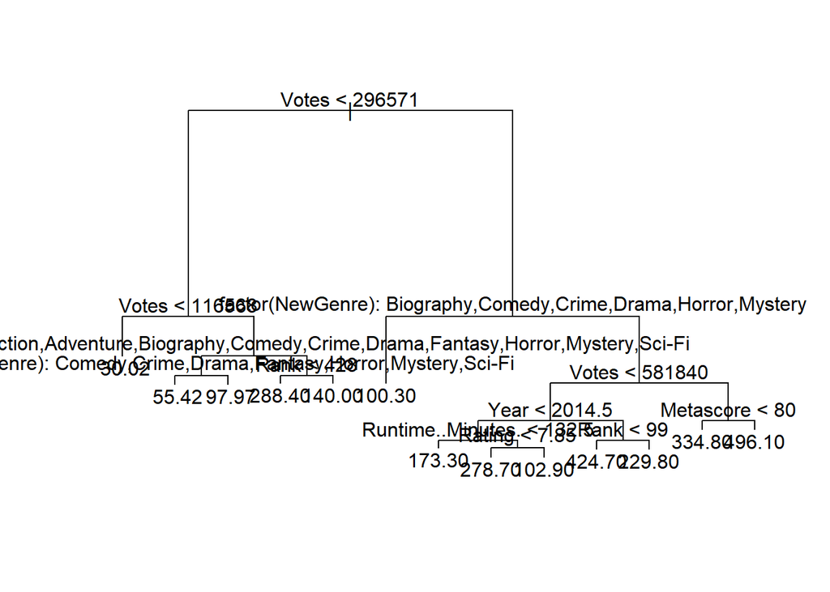

```r
plot(treeMove7)
text(treeMove7, pretty=0)
```

```r
#cvMove4<- cv.tree(treeMove7)
#summary(cvMove4)
#plot(cvMove4)
#pruneMove4 <- prune.tree(treeMove7, best =7)
#plot(pruneMove4)
#text(pruneMove4, pretty=0)
treeMove8<- tree(New_MovieDS$Revenue..Millions.~Rank+factor(NewGenre)+Year+Runtime..Minutes.+Rating+Votes+Metascore,New_MovieDS, subset=train)
summary(treeMove8)
```

```
##
## Regression tree:
## tree(formula = New_MovieDS$Revenue..Millions. ~ Rank + factor(NewGenre) +
##     Year + Runtime..Minutes. + Rating + Votes + Metascore, data = New_MovieDS,
##     subset = train)
## Variables actually used in tree construction:
## [1] "Votes"             "factor(NewGenre)"  "Runtime..Minutes."
## [4] "Rank"              "Rating"
## Number of terminal nodes:  15
## Residual mean deviance:  3057 = 1235000 / 404
## Distribution of residuals:
##    Min. 1st Qu.  Median    Mean 3rd Qu.    Max.
## -246.00  -28.65  -11.37    0.00   23.63  286.10
```

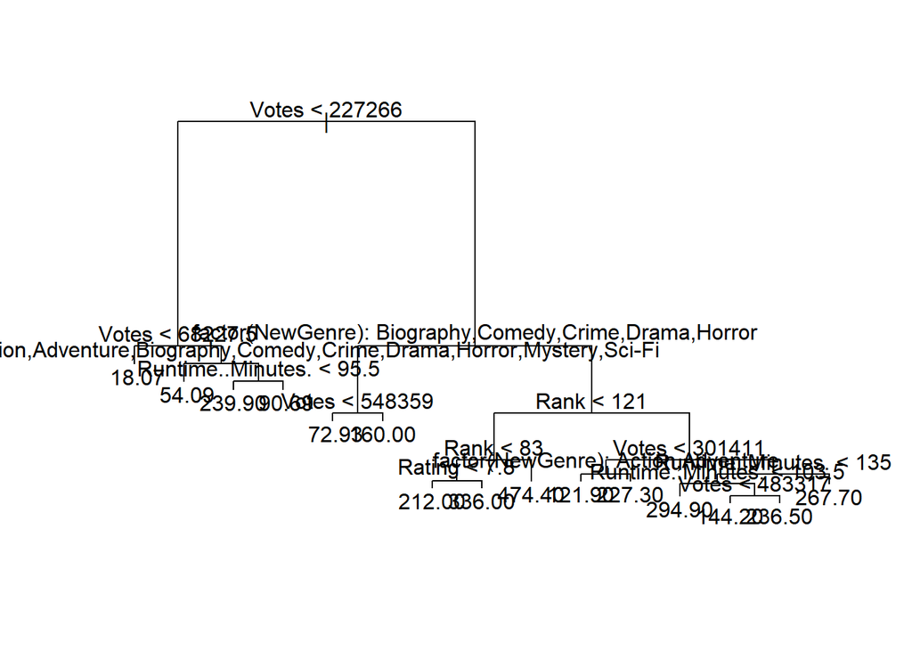

```r
plot(treeMove8)
text(treeMove8, pretty=0)
```

```r
cvMove4<- cv.tree(treeMove8)
summary(cvMove4)
```

```
##        Length Class  Mode
## size   14     -none- numeric
## dev    14     -none- numeric
## k      14     -none- numeric
## method  1     -none- character
```

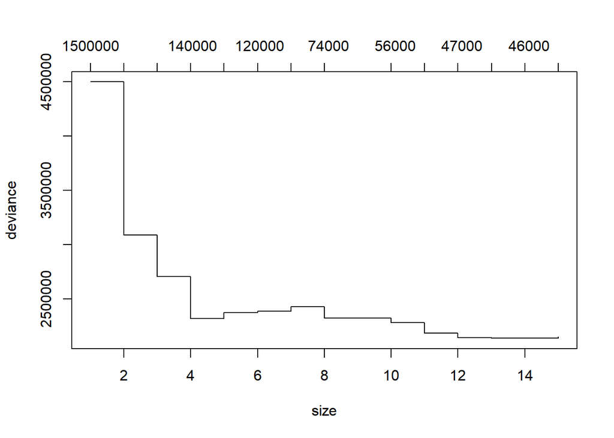

```r
plot(cvMove4)
```

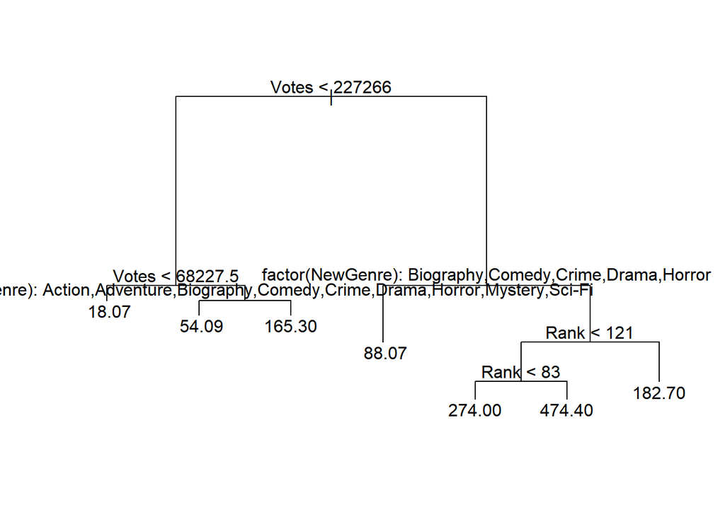

```r
pruneMove4 <- prune.tree(treeMove8, best =7)
plot(pruneMove4)
text(pruneMove4, pretty=0)
```

```r
yhat4<- predict(treeMove8, newdata=test.data)
MoveTest4<- New_MovieDS[-train, "Revenue..Millions."]
mean((yhat4-MoveTest4)^2)
```

```
## [1] 6884.542
```

MSE for revenue is 6884.54 so this tree predicts revenue within 82.97 of the true response.This is not very good but given the large variation of the revenue data its hard to tell if this is bad.

For runtime

```r
treeMove9<- tree(New_MovieDS$Runtime..Minutes.~Rank+factor(NewGenre)+Year+Rating+Votes+Revenue..Millions.+Metascore,New_MovieDS)
summary(treeMove9)
```

```
##
## Regression tree:
## tree(formula = New_MovieDS$Runtime..Minutes. ~ Rank + factor(NewGenre) +
##     Year + Rating + Votes + Revenue..Millions. + Metascore, data = New_MovieDS)
## Variables actually used in tree construction:
## [1] "Votes"              "Rating"             "factor(NewGenre)"
## [4] "Rank"               "Revenue..Millions." "Year"
## Number of terminal nodes:  13
## Residual mean deviance:  212.9 = 175600 / 825
## Distribution of residuals:
##    Min. 1st Qu.  Median    Mean 3rd Qu.    Max.
## -46.040  -9.544  -0.949   0.000   8.718  63.150
```

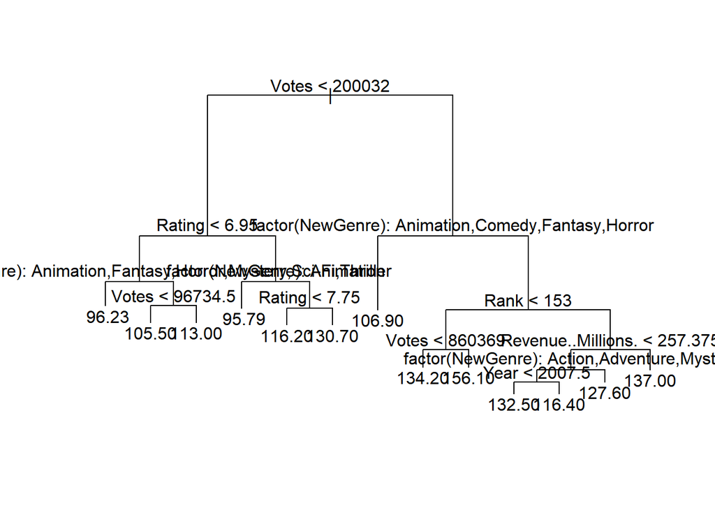

```r
plot(treeMove9)
text(treeMove9, pretty=0)
```

```r
#cvMove5<- cv.tree(treeMove9)
#summary(cvMove5)
#plot(cvMove5)
#pruneMove5 <- prune.tree(treeMove9, best =7)
#plot(pruneMove5)
#text(pruneMove5, pretty=0)
treeMove10<- tree(New_MovieDS$Runtime..Minutes.~Rank+factor(NewGenre)+Year+Rating+Votes+Revenue..Millions.+Metascore,New_MovieDS, subset=train)
summary(treeMove10)
```

```
##
## Regression tree:
## tree(formula = New_MovieDS$Runtime..Minutes. ~ Rank + factor(NewGenre) +
##     Year + Rating + Votes + Revenue..Millions. + Metascore, data = New_MovieDS,
##     subset = train)
## Variables actually used in tree construction:
## [1] "Rating"             "Votes"              "factor(NewGenre)"
## [4] "Rank"               "Revenue..Millions."
## Number of terminal nodes:  11
## Residual mean deviance:  201.8 = 82350 / 408
## Distribution of residuals:
##    Min. 1st Qu.  Median    Mean 3rd Qu.    Max.
## -36.590  -9.468  -1.000   0.000   8.145  55.040
```

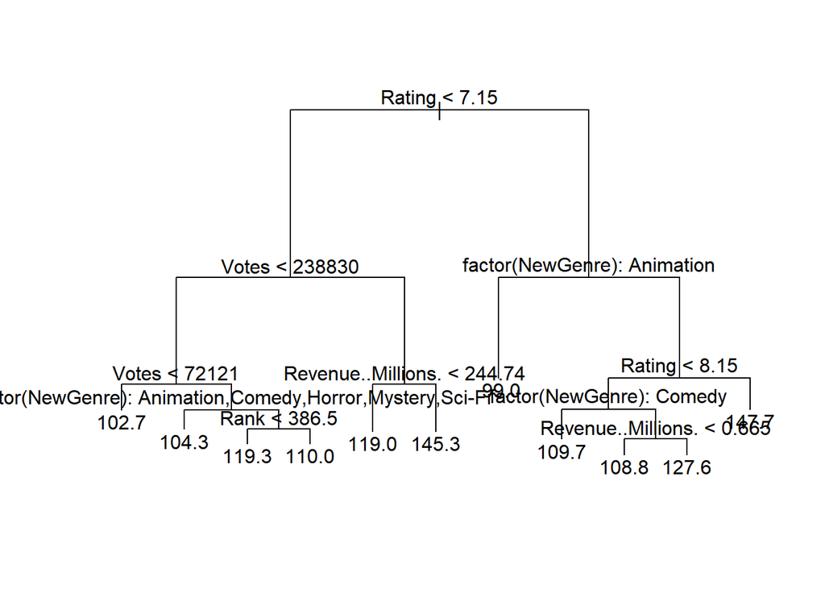

```r
plot(treeMove10)
text(treeMove10, pretty=0)
```

```r
cvMove5<- cv.tree(treeMove10)
summary(cvMove5)
```

```
##        Length Class  Mode
## size   11     -none- numeric
## dev    11     -none- numeric
## k      11     -none- numeric
## method  1     -none- character
```

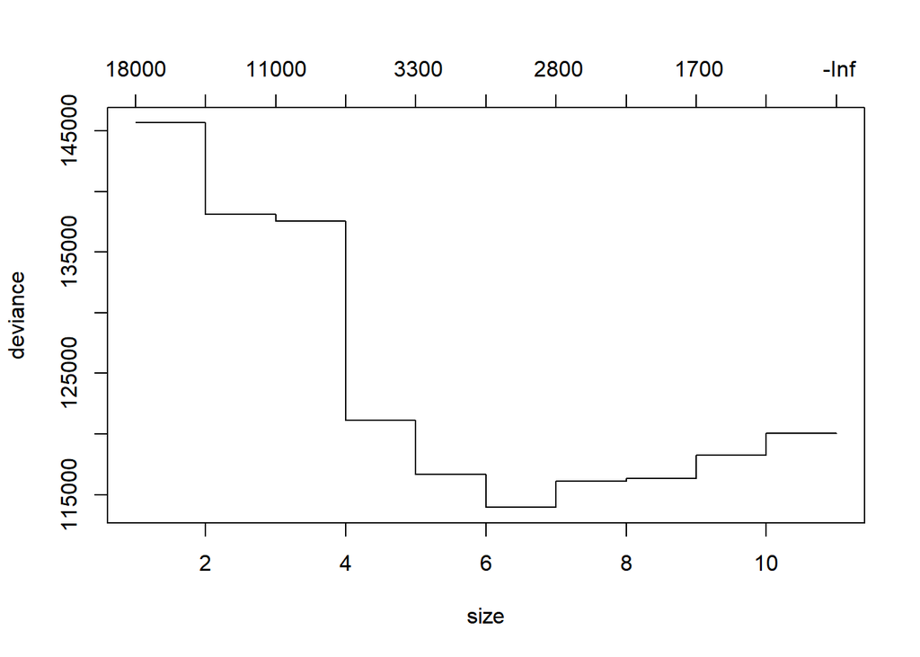

```r
plot(cvMove5)
```

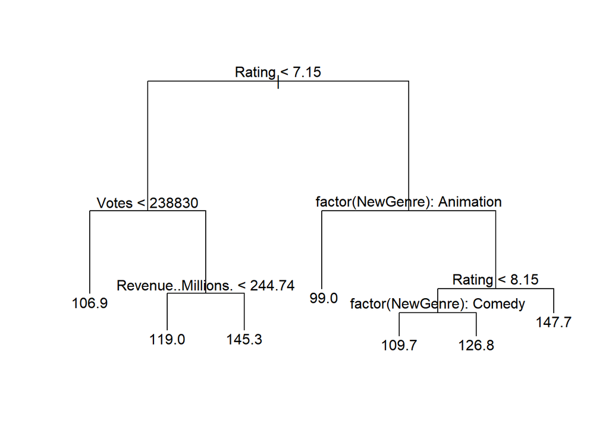

```r
pruneMove5 <- prune.tree(treeMove10, best =7)
plot(pruneMove5)
text(pruneMove5, pretty=0)
```

```r
yhat5<- predict(treeMove10, newdata=test.data)
MoveTest5<- New_MovieDS[-train, "Runtime..Minutes."]
mean((yhat5-MoveTest5)^2)
```

```
## [1] 281.439
```

MSE for runtime is 281.439 so this tree predicts runtime to within 16.78 minutes. This is not a bad prediction of the runtime

for votes

```r
treeMove11<- tree(New_MovieDS$Votes~Rank+factor(NewGenre)+Year+Runtime..Minutes.+Rating+Revenue..Millions.+Metascore,New_MovieDS)
summary(treeMove11)
```

```
##
## Regression tree:
## tree(formula = New_MovieDS$Votes ~ Rank + factor(NewGenre) +
##     Year + Runtime..Minutes. + Rating + Revenue..Millions. +
##     Metascore, data = New_MovieDS)
## Variables actually used in tree construction:
## [1] "Revenue..Millions." "Rating"             "Year"
## [4] "factor(NewGenre)"
## Number of terminal nodes:  12
## Residual mean deviance:  9.12e+09 = 7.533e+12 / 826
## Distribution of residuals:
##    Min. 1st Qu.  Median    Mean 3rd Qu.    Max.
## -333000  -49540  -12880       0   45200  580100
```

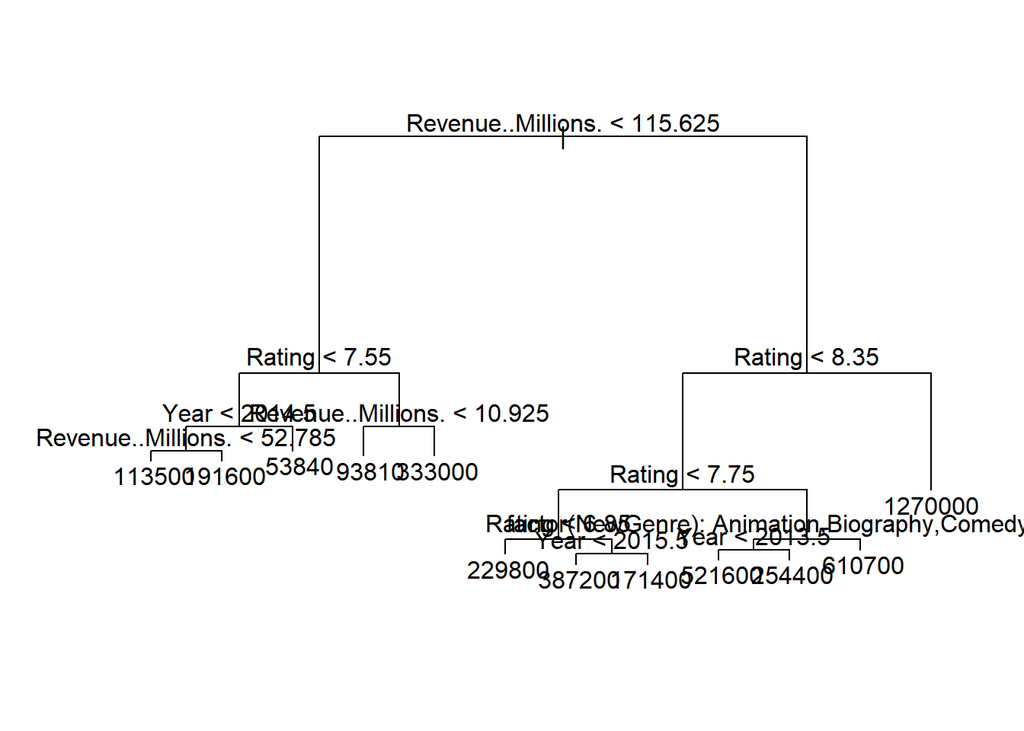

```r
plot(treeMove11)
text(treeMove11, pretty=0)
```

```r
#cvMove6<- cv.tree(treeMove11)
#summary(cvMove6)
#plot(cvMove6)
#pruneMove6 <- prune.tree(treeMove11, best =7)
#plot(pruneMove6)
#text(pruneMove6, pretty=0)
treeMove12<- tree(New_MovieDS$Votes~Rank+factor(NewGenre)+Year+Runtime..Minutes.+Rating+Revenue..Millions.+Metascore,New_MovieDS, subset=train)
summary(treeMove12)
```

```
##
## Regression tree:
## tree(formula = New_MovieDS$Votes ~ Rank + factor(NewGenre) +
##     Year + Runtime..Minutes. + Rating + Revenue..Millions. +
##     Metascore, data = New_MovieDS, subset = train)
## Variables actually used in tree construction:
## [1] "Revenue..Millions." "Rating"             "Year"
## [4] "Metascore"          "Runtime..Minutes."  "factor(NewGenre)"
## Number of terminal nodes:  11
## Residual mean deviance:  9.427e+09 = 3.846e+12 / 408
## Distribution of residuals:
##    Min. 1st Qu.  Median    Mean 3rd Qu.    Max.
## -551000  -48900  -11520       0   55110  694800
```

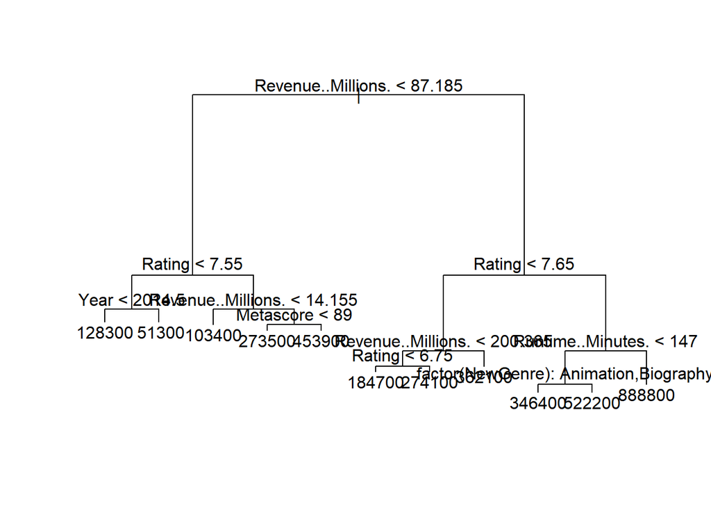

```r
plot(treeMove12)
text(treeMove12, pretty=0)
```

```r
cvMove6<- cv.tree(treeMove12)
summary(cvMove6)
```

```
##        Length Class  Mode
## size   11     -none- numeric
## dev    11     -none- numeric
## k      11     -none- numeric
## method  1     -none- character
```

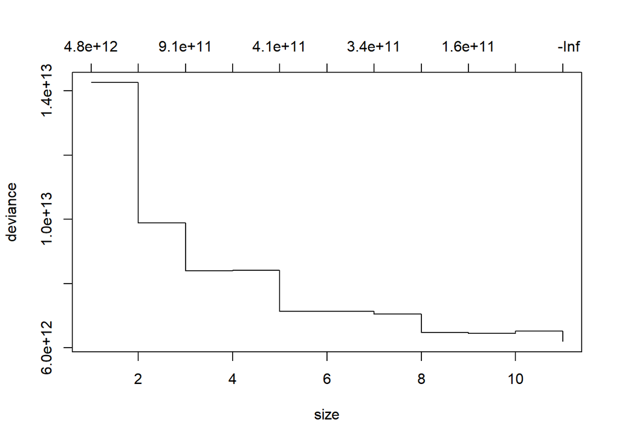

```r
plot(cvMove6)
```

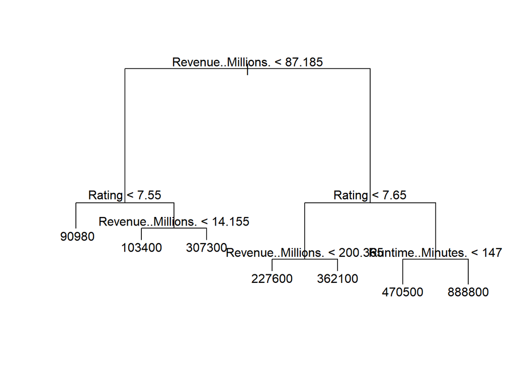

```r
pruneMove6 <- prune.tree(treeMove12, best =7)
plot(pruneMove6)
text(pruneMove6, pretty=0)
```

```r
yhat6<- predict(treeMove12, newdata=test.data)
MoveTest6<- New_MovieDS[-train, "Votes"]
mean((yhat6-MoveTest6)^2)
```

```
## [1] 17702611607
```

MSE for votes is 17702611607 so this tree predicts votes to within 133051 votes. Even with the large variance in votes data this prediction is quite bad and shows that a regression tree likely does not work for this response variable

for metascore

```r
treeMove13<- tree(New_MovieDS$Metascore~Rank+factor(NewGenre)+Year+Runtime..Minutes.+Rating+Votes+Revenue..Millions.,New_MovieDS)
summary(treeMove13)
```

```
##
## Regression tree:
## tree(formula = New_MovieDS$Metascore ~ Rank + factor(NewGenre) +
##     Year + Runtime..Minutes. + Rating + Votes + Revenue..Millions.,
##     data = New_MovieDS)
## Variables actually used in tree construction:
## [1] "Rating"           "Votes"            "factor(NewGenre)"
## Number of terminal nodes:  6
## Residual mean deviance:  145.4 = 120900 / 832
## Distribution of residuals:
##     Min.  1st Qu.   Median     Mean  3rd Qu.     Max.
## -41.2100  -7.7450  -0.2058   0.0000   7.7940  34.6000
```

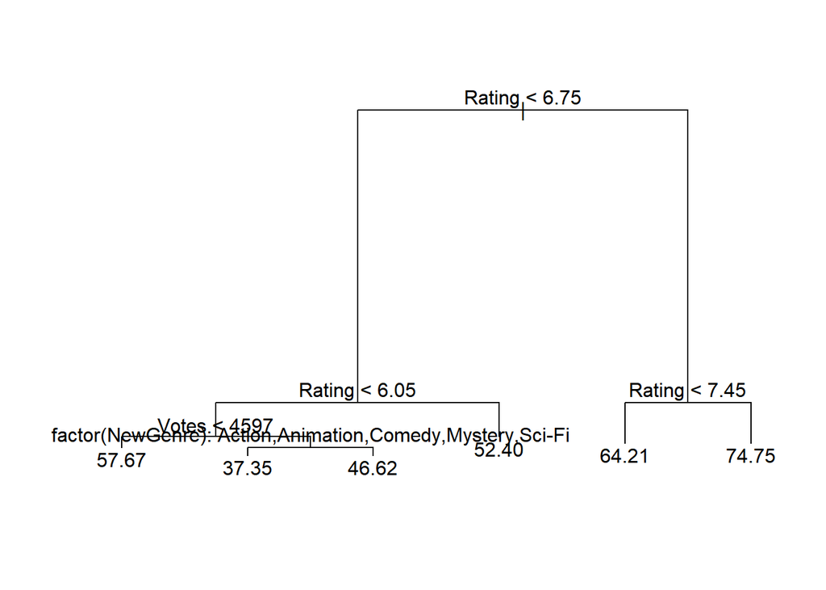

```r
plot(treeMove13)
text(treeMove13, pretty=0)
```

```r
#cvMove7<- cv.tree(treeMove13)
#summary(cvMove7)
#plot(cvMove7)
#pruneMove7 <- prune.tree(treeMove13, best =4)
#plot(pruneMove7)
#text(pruneMove7, pretty=0)
treeMove14<- tree(New_MovieDS$Metascore~Rank+factor(NewGenre)+Year+Runtime..Minutes.+Rating+Votes+Revenue..Millions.,New_MovieDS, subset=train)
summary(treeMove14)
```

```
##
## Regression tree:
## tree(formula = New_MovieDS$Metascore ~ Rank + factor(NewGenre) +
##     Year + Runtime..Minutes. + Rating + Votes + Revenue..Millions.,
##     data = New_MovieDS, subset = train)
## Variables actually used in tree construction:
## [1] "Rating"           "factor(NewGenre)" "Votes"
## Number of terminal nodes:  7
## Residual mean deviance:  124.6 = 51330 / 412
## Distribution of residuals:
##      Min.   1st Qu.    Median      Mean   3rd Qu.      Max.
## -40.26000  -7.20300  -0.05556   0.00000   7.60600  39.83000
```

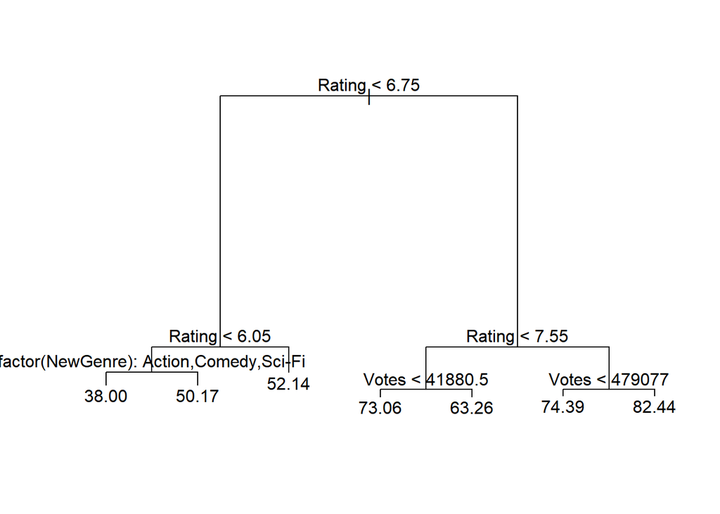

```r
plot(treeMove14)
text(treeMove14, pretty=0)
```

```r
cvMove7<- cv.tree(treeMove14)
summary(cvMove7)
```

```
##        Length Class  Mode
## size   7      -none- numeric
## dev    7      -none- numeric
## k      7      -none- numeric
## method 1      -none- character
```

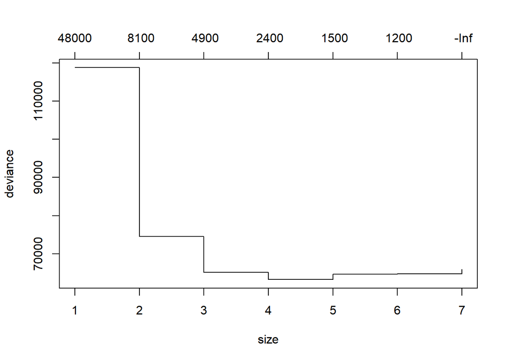

```r
plot(cvMove7)
```

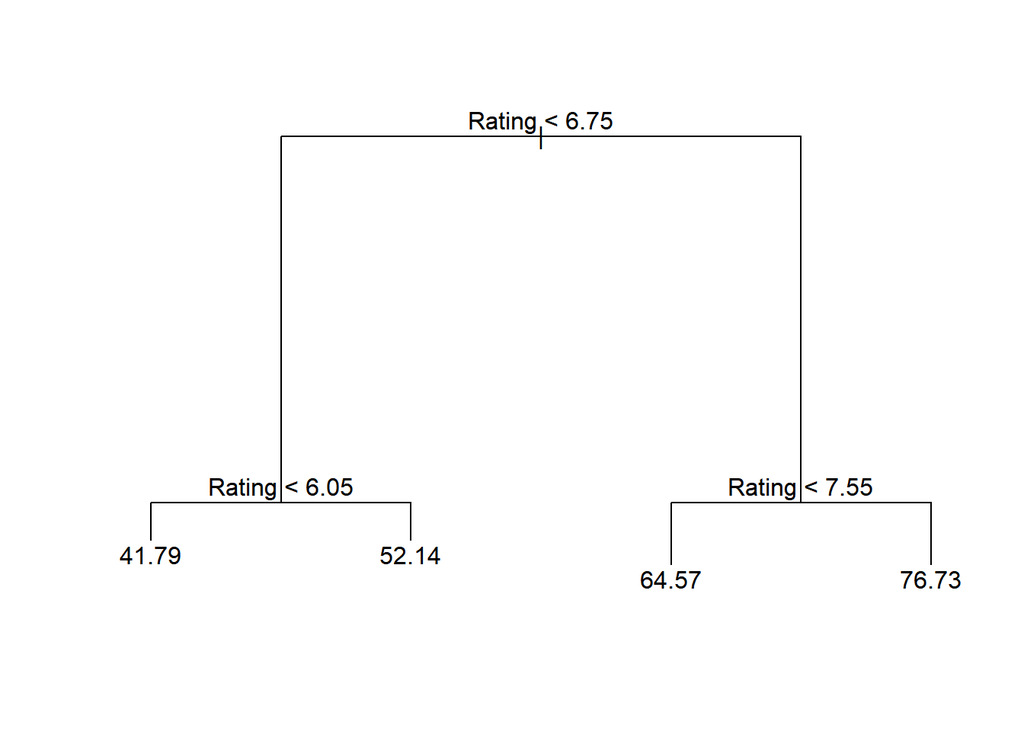

```r
pruneMove7 <- prune.tree(treeMove14, best =4)
plot(pruneMove7)
text(pruneMove7, pretty=0)
```

```r
yhat7<- predict(treeMove14, newdata=test.data)
MoveTest7<- New_MovieDS[-train, "Metascore"]
mean((yhat7-MoveTest7)^2)
```

```
## [1] 176.9805
```

MSE for metascore is 176.9805 so this tree predicts metascore within 13.30 points. While this might not be the best model for predicting metascore it is not bad.

## Boosting

For rating

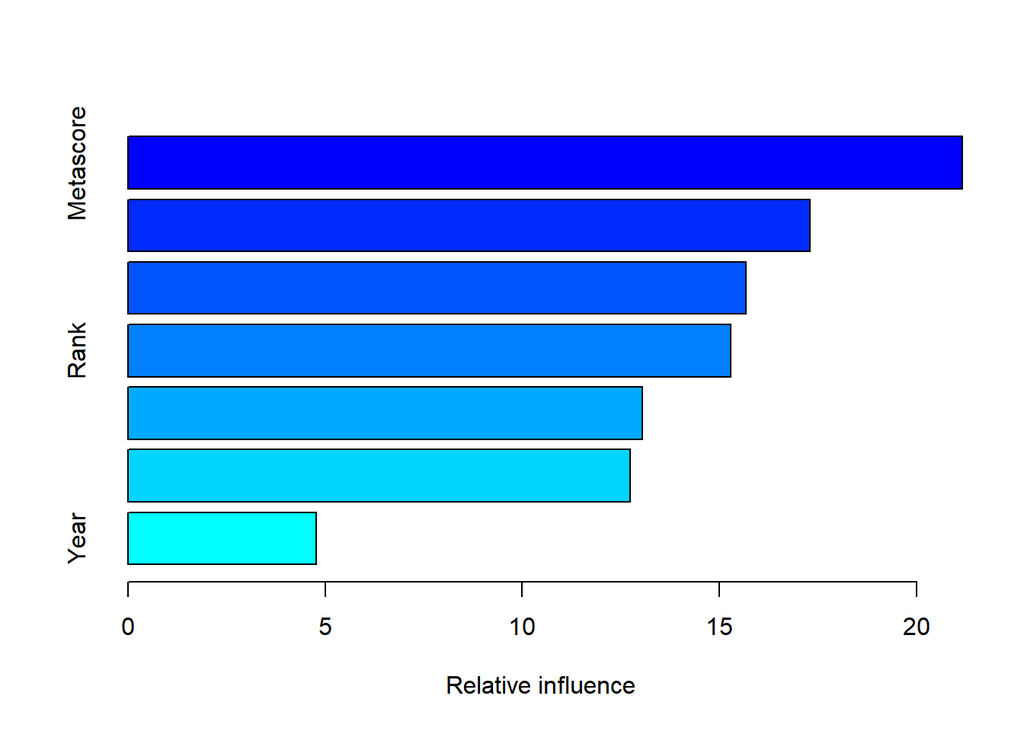

```
##                                   var   rel.inf
## Metascore                   Metascore 21.164956
## factor(NewGenre)     factor(NewGenre) 17.298503
## Votes                           Votes 15.676036
## Rank                             Rank 15.296125
## Revenue..Millions. Revenue..Millions. 13.050401
## Runtime..Minutes.   Runtime..Minutes. 12.746571
## Year                             Year  4.767408
```

```r
library(gbm)
library(gclus)
#rain<-sample (1: nrow(New_MovieDS), nrow(New_MovieDS)/2)
#train.data <-New_MovieDS[rain,]
#move <- New_MovieDS[-train, ]
moveBoost<-gbm(Rating~Rank+factor(NewGenre)+Year+Runtime..Minutes.+Votes+Revenue..Millions.+Metascore,distribution="gaussian", data=train.data, n.trees=5000, interaction.depth=1)
summary(moveBoost)
```

```r
#table(train.data$Rating, predict(moveBoost, newdata=train.data, type="response", n.trees=5000)>0.5 )
yhatBoost<-predict(moveBoost, newdata=test.data,n.trees=5000)
boostMoveTest<- New_MovieDS[-train, "Rating"]
mean((yhatBoost-boostMoveTest)^2)
```

```
## [1] 0.3856414
```

For Rank

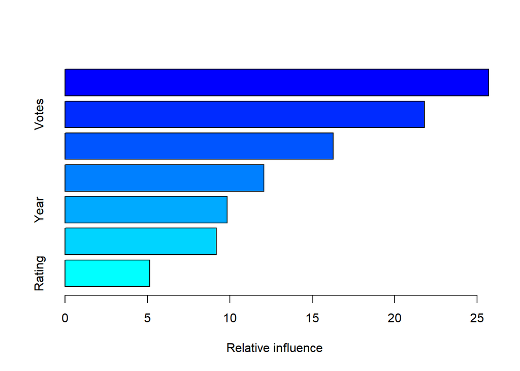

```
##                                   var   rel.inf
## factor(NewGenre)     factor(NewGenre) 25.704074
## Votes                           Votes 21.802296
## Revenue..Millions. Revenue..Millions. 16.264975
## Runtime..Minutes.   Runtime..Minutes. 12.058484
## Year                             Year  9.847025
## Metascore                   Metascore  9.173539
## Rating                         Rating  5.149608
```

```r
moveBoost2<-gbm(Rank~factor(NewGenre)+Year+Runtime..Minutes.+Rating+Votes+Revenue..Millions.+Metascore,distribution="gaussian", data=train.data, n.trees=5000, interaction.depth=1)
summary(moveBoost2)
```

```r
#table(train.data$Rank, predict(moveBoost2, newdata=train.data, type="response", n.trees=5000)>0.5 )
yhatBoost2<-predict(moveBoost2, newdata=test.data,n.trees=5000)
boostMoveTest2<- New_MovieDS[-train, "Rank"]
mean((yhatBoost2-boostMoveTest2)^2)
```

```
## [1] 61299.74
```

For NewGenre

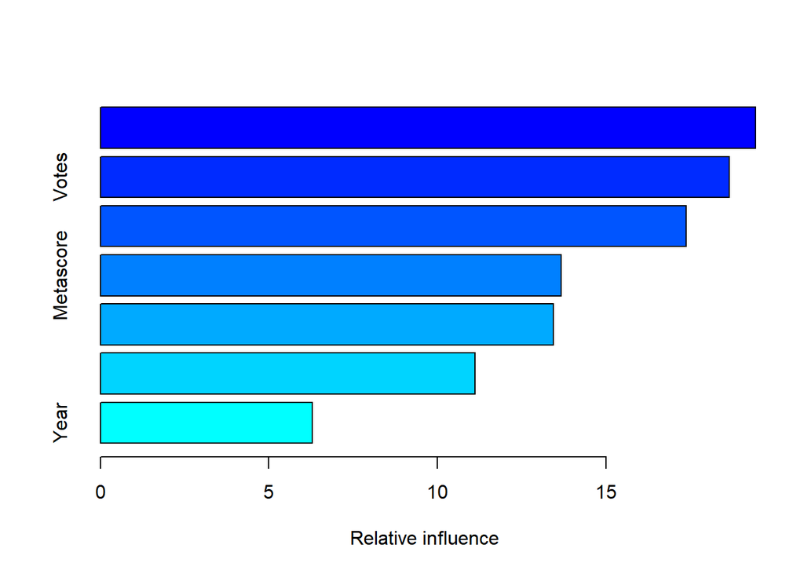

```
##                                   var   rel.inf
## Revenue..Millions. Revenue..Millions. 19.443817
## Votes                           Votes 18.661827
## Rank                             Rank 17.380083
## Metascore                   Metascore 13.667346
## Runtime..Minutes.   Runtime..Minutes. 13.443003
## Rating                         Rating 11.120460
## Year                             Year  6.283464
```

```r
moveBoost3<-gbm(factor(NewGenre)~Rank+Year+Runtime..Minutes.+Rating+Votes+Revenue..Millions.+Metascore,distribution="gaussian", data=train.data, n.trees=5000, interaction.depth=1)
summary(moveBoost3)
```

```r
#table(train.data$NewGenre, predict(moveBoost3, newdata=train.data, type="response", n.trees=5000)>0.5 )
yhatBoost3<-predict(moveBoost3, newdata=test.data,n.trees=5000)
boostMoveTest3<- New_MovieDS[-train, "NewGenre"]
mean((yhatBoost3-boostMoveTest3)^2)
```

```
## [1] NA
```

MSE = NA makes semse as categorical not numeric

For Revenue

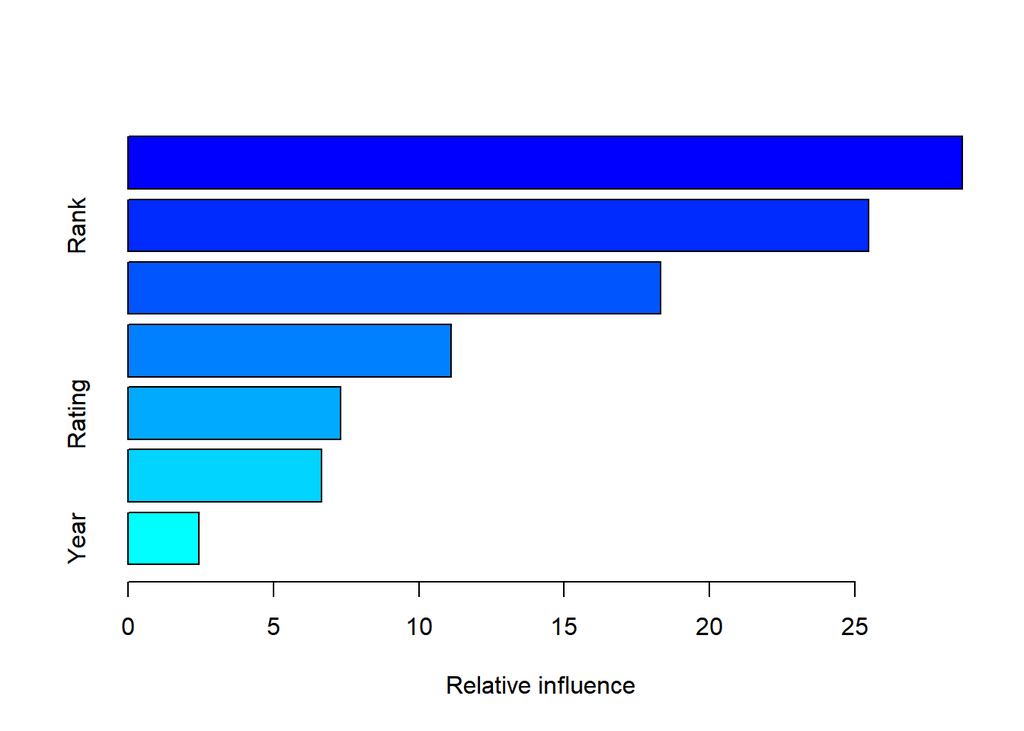

```
##                                 var   rel.inf
## Votes                         Votes 28.685008
## Rank                           Rank 25.463958
## factor(NewGenre)   factor(NewGenre) 18.327174
## Runtime..Minutes. Runtime..Minutes. 11.102014
## Rating                       Rating  7.320832
## Metascore                 Metascore  6.651105
## Year                           Year  2.449909
```

```r
moveBoost4<-gbm(Revenue..Millions.~Rank+factor(NewGenre)+Year+Runtime..Minutes.+Rating+Votes+Metascore,distribution="gaussian", data=train.data, n.trees=5000, interaction.depth=1)
summary(moveBoost4)
```

```r
#table(train.data$Revenue..Millions., predict(moveBoost4, newdata=train.data, type="response", n.trees=5000)>0.5 )
yhatBoost4<-predict(moveBoost4, newdata=test.data,n.trees=5000)
boostMoveTest4<- New_MovieDS[-train, "Revenue..Millions."]
mean((yhatBoost4-boostMoveTest4)^2)
```

```
## [1] 6537.284
```

For runttime

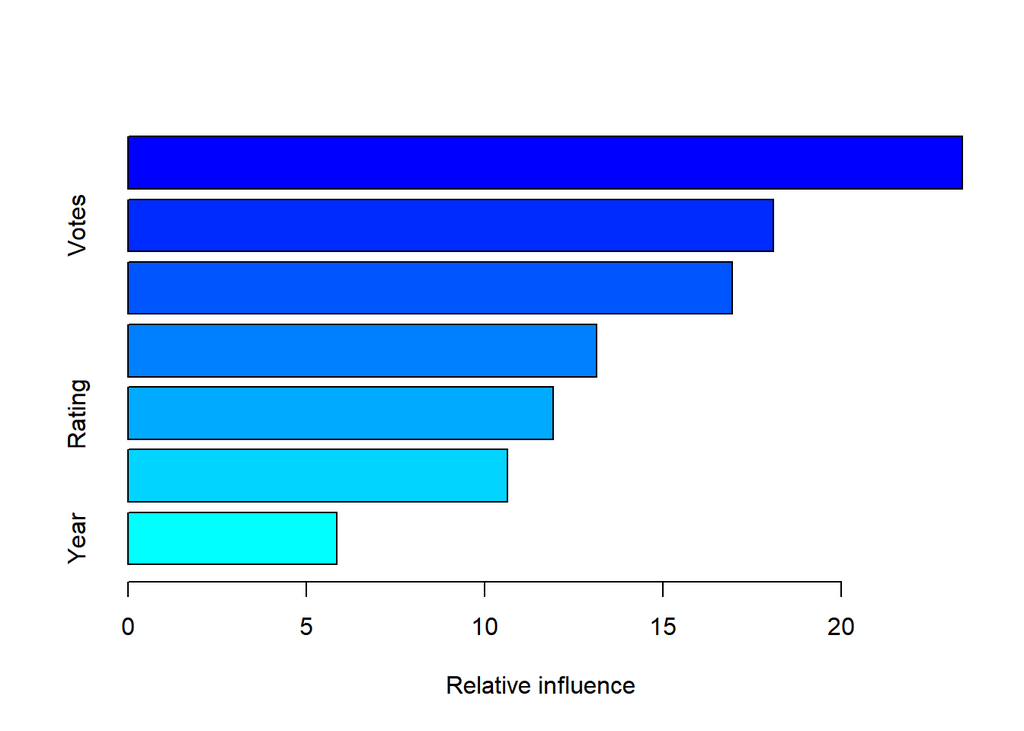

```
##                                   var   rel.inf
## factor(NewGenre)     factor(NewGenre) 23.394977
## Votes                           Votes 18.093307
## Revenue..Millions. Revenue..Millions. 16.943976
## Rank                             Rank 13.132365
## Rating                         Rating 11.915837
## Metascore                   Metascore 10.652510
## Year                             Year  5.867028
```

```r
moveBoost5<-gbm(Runtime..Minutes.~Rank+factor(NewGenre)+Year+Rating+Votes+Revenue..Millions.+Metascore,distribution="gaussian", data=train.data, n.trees=5000, interaction.depth=1)
summary(moveBoost5)
```

```r
#table(train.data$Runtime..Minutes, predict(moveBoost5, newdata=train.data, type="response", n.trees=5000)>0.5 )
yhatBoost5<-predict(moveBoost5, newdata=test.data,n.trees=5000)
boostMoveTest5<- New_MovieDS[-train, "Runtime..Minutes."]
mean((yhatBoost5-boostMoveTest5)^2)
```

```
## [1] 337.2597
```

For votes

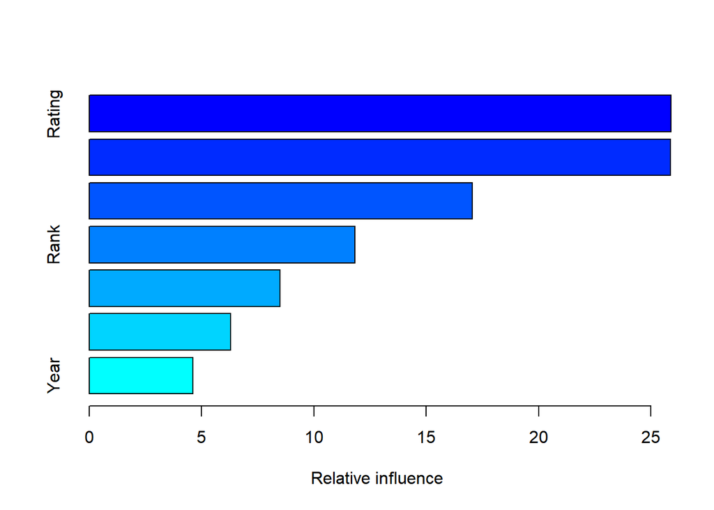

```
##                                   var   rel.inf
## Rating                         Rating 25.885722
## Revenue..Millions. Revenue..Millions. 25.865499
## Runtime..Minutes.   Runtime..Minutes. 17.054096
## Rank                             Rank 11.816510
## factor(NewGenre)     factor(NewGenre)  8.483495
## Metascore                   Metascore  6.289225
## Year                             Year  4.605453
```

```r
moveBoost6<-gbm(Votes~Rank+factor(NewGenre)+Year+Runtime..Minutes.+Rating+Revenue..Millions.+Metascore,distribution="gaussian", data=train.data, n.trees=5000, interaction.depth=1)
summary(moveBoost6)
```

```r
#table(train.data$Votes, predict(moveBoost6, newdata=train.data, type="response", n.trees=5000)>0.5 )
yhatBoost6<-predict(moveBoost6, newdata=test.data,n.trees=5000)
boostMoveTest6<- New_MovieDS[-train, "Votes"]
mean((yhatBoost6-boostMoveTest6)^2)
```

```
## [1] 14787251560
```

For metascore

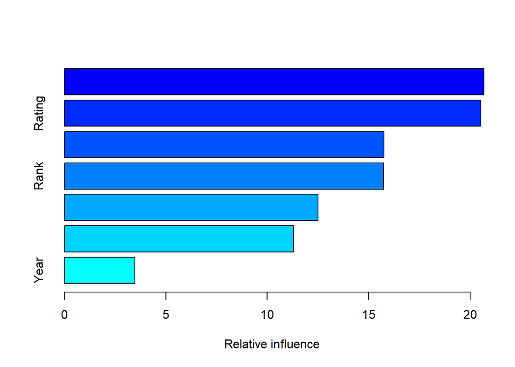

```
##                                   var   rel.inf
## factor(NewGenre)     factor(NewGenre) 20.680597
## Rating                         Rating 20.536254
## Votes                           Votes 15.762912
## Rank                             Rank 15.738301
## Revenue..Millions. Revenue..Millions. 12.504557
## Runtime..Minutes.   Runtime..Minutes. 11.296676
## Year                             Year  3.480703
```

```r
moveBoost7<-gbm(Metascore~Rank+factor(NewGenre)+Year+Runtime..Minutes.+Rating+Votes+Revenue..Millions.,distribution="gaussian", data=train.data, n.trees=5000, interaction.depth=1)
summary(moveBoost7)
```

```r
#table(train.data$Metascore, predict(moveBoost7, newdata=train.data, type="response", n.trees=5000)>0.5 )
yhatBoost7<-predict(moveBoost7, newdata=test.data,n.trees=5000)
boostMoveTest7<- New_MovieDS[-train, "Metascore"]
mean((yhatBoost7-boostMoveTest7)^2)
```

```
## [1] 194.5849
```